[figure not shown]

# Aula 25

## Processamento de Linguagem Natural & Análise de Sentimento

Este é um tutorial introdutório ao Processamento de Língua Natural *(Natural Language Processing, NLP)* e Análise de Sentimentos *(Sentiment Analysis)* visando apresentar os principais conceitos e métodos.

#### O que é?

NLP é um dos grandes campos de pesquisa de Inteligência Artificial, focado no tratamento, entendimento e interpretação de língua natural. Ao invés de termos dados estruturados em tabelas, colunas e linhas, *e.g.,* e preenchidos de acordo com algum padrão pré-definido ou até mesmo preenchido de mandeira pragmática, temos **dados desestruturados e textos livres**.

#### Casos de NLP

- Reconhecimento de fala *(Automatic Speech Recognition - ASR, )*
- Agentes conversacionais *(chatbots)*
- Tradução de textos *(Machine Translation)*
- Transcrição de textos
- Mineração de textos *(Text Mining)*
- Mineração de redes sociais
- Categorização, simplificação ou sumarização de textos
- Reconhecimento de Entidades *(Named Entity Recognition)*
- Análise de Sentimento *(Sentiment Analysis)*
- Etc.

#### Como funciona?

Claro que nada disso é mágica e tudo é realizado através de técnicas e análises léxicas, sintáticas e semânticas, além da compreensão de questões cognitivas, psicolinguísticas e estatísticas. **Jurafsky e Martin** descrevem NLP da seguinte forma em seu livro$^{1}$:

> *"No mínimo, um agente deve ser capaz de interagir com humanos por uma língua natural, o que inclui o entendimento de humanos através de uma do recohecimento de fala e língua natural (e, claro, leitura labial), e a comunicação com seres humanos por geração de língua natural e sintetização de fala. Também deveria ser capaz de recuperar informações (descobrir quais recursos textuais são necessários), extrair informações (fatos pertinentes a partir destes recursos) e inferir (desenhar conclusões baseadas em fatos conhecidos.*

Claramente estamos muito longe disso, muito longe de passar pelo teste de *Turing*$^{2}$. Ainda temos bastante dificuldade em compreender características comportamentais, sentimentais e filosóficas. Uma máquina ainda não é capaz de simular sentimentos **reais** (não apenas "positivo" e "negativo") ou compreender contextos. A falta de recursos (*córpus*, textos rotulados, etc) é gritante, especialmente para idiomas não tão populares (sim, nosso Português se enquadra aqui!).

Existe muita divergência no mercado sobre a realidade e o que **de fato** foi construído no estado-da-arte, mas uma frase de **Chomsky**$^{3}$ relata muito bem a realidade:

> *"Pouco pode ser dito com qualquer confiança a respeito da "arquitetura" da mente humana, e por esta razão eu propositalmente permaneço confuso em todo este tópico."*

Também gosto da visão de um grande pesquisador brasileiro chamado **Miguel Nicolelis** explanada em seu livro$^{4}$. sobre como ser capazes de simular *completamente* o cérebro humano, justamente pela forma como nosso sistema nervoso funciona.

#### Cursos

- [Natural Language Processing](https://www.youtube.com/watch?v=CXpZnZM63Gg&list=PL8FFE3F391203C98C), Stanford (by Jurafsky)
- [Sequence Models](https://www.coursera.org/learn/nlp-sequence-models), Coursera (by Andrew Ng @deeplearning.ai)
- [CS224n: Natural Language Processing with Deep Learning](http://web.stanford.edu/class/cs224n/), Stanford
- [Miracles of Human Language: An Introduction to Linguistics](https://www.coursera.org/learn/human-language), Coursera (by Universiteit Leiden, Meertens instituut, KNAW)

$^{1}$ [Speech and Language Processing, 2nd Edition](https://www.amazon.com/Speech-Language-Processing-Daniel-Jurafsky/dp/0131873210), Dan Jurafsky and James H. Martin  
$^{2}$ [Turing Test](http://www.psych.utoronto.ca/users/reingold/courses/ai/turing.html), University of Toronto $^{3}$ [An On-Line Interview with Noam Chomsky: On the nature of pragmatics and related issues](http://www.cogprints.org/126/1/chomsweb_399.html), Brain and Language, Volume 68, # 3, July 1999, pp. 393-401 $^{4}$ [O Cerebro Relativistico: Como Ele Funciona E Por Que Ele Não Pode Ser Simulado Por Uma Máquina de Turing](https://www.amazon.com.br/Cerebro-Relativistico-Funciona-Simulado-Maquina/dp/151463810X?tag=goog0ef-20&smid=A1ZZFT5FULY4LN&ascsubtag=46cb126c-655c-4a38-a18e-3f2f5089ce45), Miguel Nicolelis

[figure not shown]

### Caso de Uso

Vamos utilizar dados coletados no Twitter através da [API de Streaming](https://developer.twitter.com/en/docs/tutorials/consuming-streaming-data.html) durante um jogo da Copa do Mundo FIFA 2018 na Rússia: **Brasil vs. Costa Rica** na manhã de 22/06/2018.

A ideia é brincar bastante com língua natural e nada melhor do que publicações do Twitter.

Você pode pensar *"poxa, mas de novo Twitter"* ou *"isso não tem nada a ver com a realidade e não é um case que vou aplicar no mercado de trabalho"*, mas acreditem: **todas as empresas** querem ou já mineram dados de redes sociais.

Até gostaria de explorar o Facebook ou o LinkedIn, porém estas plataformas são fechadas e não disponibilizam nenhuma biblioteca ou API para a coleta de dados públicos.

### Dataset

Foram coletados *tweets* em **Português** das **08:55** até **12:55**, também quero "medir" as reações de pós-jogo.

Afinal, a zueira do *hue hue* brasileiro deve ser apreciada.

[figure not shown]

### Atributos

O arquivo **tweets.csv** (~150MB) já está tratado e possui as seguintes [características](https://developer.twitter.com/en/docs/tweets/data-dictionary/overview/tweet-object):

- **favorite_count**: indica aproximadamente quantas vezes o *tweet* foi curtido;
- **favorited**: indica se o *tweet* foi curtido pelo usuário autenticado;
- **is_quote_status**: indica se o *tweet* é uma menção ou não;
- **lang**: idioma da postagem;
- **possibly_sensitive**: se o *tweet* possui um *link* com conteúdo sensível;
- **quote_count**: indica aproximadamente quantas vezes o *tweet* foi mencionado;
- **reply_count**: quantidade de respostas ao *tweet*;
- **retweet_count**: quantidade de *retweets*;
- **retweeted**: indica se o *tweet* é um *retweet* ou não;
- **source**: fonte da postagem (desktop, android, etc);
- **text**: texto do *tweet*;
- **username**: nome do usuário;
- **data**: data da postagem;
- **year**: ano da postagem;
- **month**: mês da postagem;
- **day**: dia da postagem;
- **hour**: hora da postagem;
- **minute**: minuto da postagem;
- **second**: segundo da postagem;

**Existem outros atributos no JSON fornecido pela API, porém, não são relevantes para o conteúdo desta aula.*

## Configuração inicial

**Pandas**: biblioteca para manipulação de dados

```python
import pandas as pd
```

```python
pd.set_option('display.max_rows', 500)
pd.set_option('display.max_columns', 500)
pd.set_option('max_colwidth', 1500)
```

**Numpy**: biblioteca científica para manipulação de valores numéricos.

```python
import numpy as np
```

**gc**: limpeza de dados em memória.

```python
import gc
```

**Matplotlib, seaborn:** bibliotecas para visualização de dados.

```python
import matplotlib.pyplot as plt
import seaborn as sns
color = sns.color_palette()
sns.set(style="white")

%matplotlib inline
```

**spaCy:** biblioteca para processamento de língua natural:

```
!conda install -c conda-forge spacy -y
```

```python
import spacy
from spacy import displacy
```

## Leitura de Dados

Os dados também estão disponíveis na [nuvem](https://s3.amazonaws.com/rayssak-tera/data/tweets.csv) caso prefiram ler diretamente de lá para evitar arquivos locais.

```
pd.read_csv('s3n://rayssak-tera/data/tweets-processed.csv', encoding='utf-8', index_col=0)
```

```python
tweets = pd.read_csv('data/tweets-processed.csv', encoding='utf-8', index_col=0)
```

```python
tweets.iloc[:10]
```

|  | favorite_count | favorited | is_quote_status | lang | possibly_sensitive | quote_count | reply_count | retweet_count | retweeted | source | text | username | data | year | month | day | hour | minute | second | text_clean |
| --- | --- | --- | --- | --- | --- | --- | --- | --- | --- | --- | --- | --- | --- | --- | --- | --- | --- | --- | --- | --- |
| 0 | 0.0 | 0.0 | 0.0 | pt | NaN | 0.0 | 0.0 | 0.0 | 0.0 | Twitter Web Client | RT @cleytu: pelo amor de deus brasil eu não acordei cedo pra ver vcs perdendo hein | Cl4teia | 2018-06-22 08:55:40-03:00 | 2018.0 | 6.0 | 22.0 | 8.0 | 55.0 | 40.0 | @cleytu : pelar amor deus brasil acordar ceder pra vcs perder hein |
| 1 | 0.0 | 0.0 | 0.0 | pt | NaN | 0.0 | 0.0 | 0.0 | 0.0 | Twitter for Android | RT @infitywar: HINO DO BRASIL O MAIS LINDO DE TODOS FALO COM TRANQUILIDADE | protectangelina | 2018-06-22 08:55:40-03:00 | 2018.0 | 6.0 | 22.0 | 8.0 | 55.0 | 40.0 | @infitywar : hino brasil o lindar falir tranquilidade |
| 2 | 0.0 | 0.0 | 0.0 | pt | NaN | 0.0 | 0.0 | 0.0 | 0.0 | Twitter for iPhone | VAMO BRASIL PELA AMOR DE DEUS | ohfuckingjb | 2018-06-22 08:55:40-03:00 | 2018.0 | 6.0 | 22.0 | 8.0 | 55.0 | 40.0 | brasil pelar amor deus |
| 3 | 0.0 | 0.0 | 0.0 | pt | NaN | 0.0 | 0.0 | 0.0 | 0.0 | Twitter for Android | RT @uebrisei: qm acordou cedo só p vê o brasil jogar rt aí | aiqdepreshawn | 2018-06-22 08:55:40-03:00 | 2018.0 | 6.0 | 22.0 | 8.0 | 55.0 | 40.0 | @uebrisei : qm acordar ceder só p o brasil jogar |
| 4 | 0.0 | 0.0 | 0.0 | pt | 0.0 | 0.0 | 0.0 | 0.0 | 0.0 | Twitter for Android | RT @SeriesBrasil: HINO NACIONAL DO BRASIL https://t.co/0NrBjp3qW6 | mazzikeen | 2018-06-22 08:55:40-03:00 | 2018.0 | 6.0 | 22.0 | 8.0 | 55.0 | 40.0 | @seriesbrasil : hino nacional brasil https://t.co/0nrbjp3qw6 |
| 5 | 0.0 | 0.0 | 0.0 | pt | 0.0 | 0.0 | 0.0 | 0.0 | 0.0 | Twitter for Android | RT @Emiiteuss: Um medo? — Brasil não ser HEXACAMPEÃO https://t.co/fXXaGkZhFr | YagoW7 | 2018-06-22 08:55:41-03:00 | 2018.0 | 6.0 | 22.0 | 8.0 | 55.0 | 41.0 | @emiiteuss : medo ? -- brasil hexacampeão https://t.co/fxxagkzhfr |
| 6 | 0.0 | 0.0 | 0.0 | pt | 0.0 | 0.0 | 0.0 | 0.0 | 0.0 | Twitter for Android | RT @SeriesBrasil: HINO NACIONAL DO BRASIL https://t.co/0NrBjp3qW6 | aidaandrade_ | 2018-06-22 08:55:40-03:00 | 2018.0 | 6.0 | 22.0 | 8.0 | 55.0 | 40.0 | @seriesbrasil : hino nacional brasil https://t.co/0nrbjp3qw6 |
| 7 | 0.0 | 0.0 | 0.0 | pt | 0.0 | 0.0 | 0.0 | 0.0 | 0.0 | Twitter Web Client | GLOBO AO VIVO HD 22/06/2018 - Brasil x Costa Rica https://t.co/3eILVTpdG6 via @YouTubeasd | OrionRegis | 2018-06-22 08:55:40-03:00 | 2018.0 | 6.0 | 22.0 | 8.0 | 55.0 | 40.0 | globo o o viver hd 22/06/2018 - brasil x costa rico https://t.co/3eilvtpdg6 @youtubeasd |
| 8 | 0.0 | 0.0 | 0.0 | pt | NaN | 0.0 | 0.0 | 0.0 | 0.0 | Twitter for Android | Primeiramente, bom dia, segundamente, VAI BRASIL!!!!! | Cah_reis5 | 2018-06-22 08:55:40-03:00 | 2018.0 | 6.0 | 22.0 | 8.0 | 55.0 | 40.0 | primeiramente , , segundamente , brasil ! ! ! ! ! |
| 9 | 0.0 | 0.0 | 0.0 | pt | 0.0 | 0.0 | 0.0 | 0.0 | 0.0 | Twitter for iPhone | RT @citoucicero: É sexta-feira, amor.\nVai Brasil caralho! https://t.co/7vCMR1Lffz | larygcastro | 2018-06-22 08:55:40-03:00 | 2018.0 | 6.0 | 22.0 | 8.0 | 55.0 | 40.0 | @citoucicero : - feirar , amor . brasil caralho ! https://t.co/7vcmr1lffz |

## Exploração de Dados

Temos uma base com um total de **676.375** *tweets*.

```python
len(tweets)
```

```
676375
```

Vamos plotar a frequencia dos *tweets* durante a **primeira hora** do jogo.

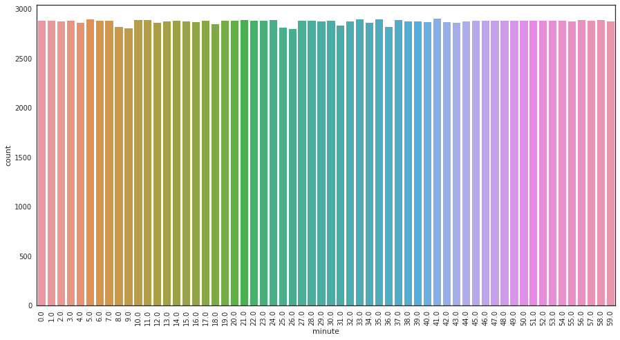

```python
fig, ax = plt.subplots(figsize=(15,8))
sns.countplot(x='minute', data=tweets.loc[tweets['hour']==9])
plt.xticks(rotation=90)
plt.show()
```

Vamos ver o **segundo tempo** (10h às 11h).

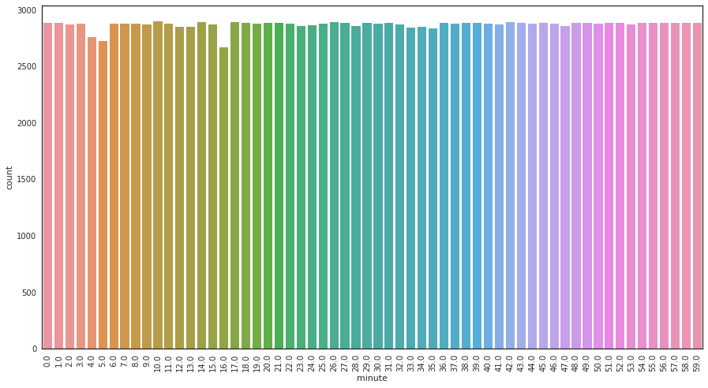

```python
fig, ax = plt.subplots(figsize=(15,8))
sns.countplot(x='minute', data=tweets.loc[tweets['hour']==10])
plt.xticks(rotation=90)
plt.show()
```

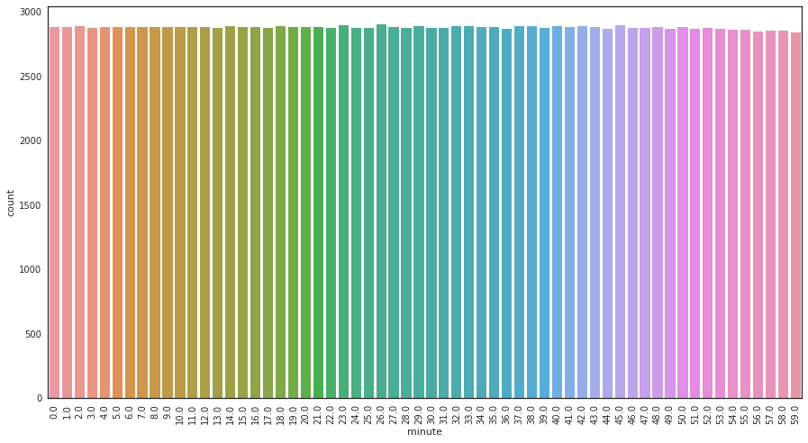

```python
fig, ax = plt.subplots(figsize=(15,8))
sns.countplot(x='minute', data=tweets.loc[tweets['hour']==11])
plt.xticks(rotation=90)
plt.show()
```

Em uma única imagem, vemos a frequencia muito menor a partir das 12h quando o jogo já estava encerrado há um tempo:

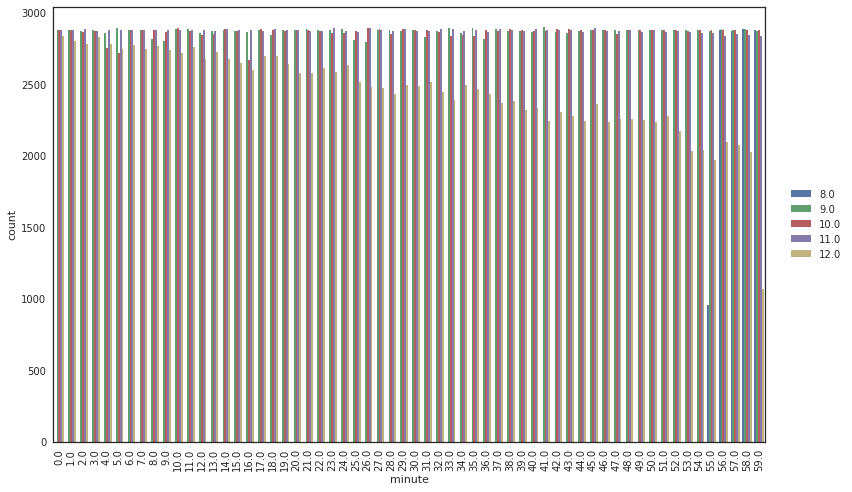

```python
fig, ax = plt.subplots(figsize=(15,8))
gplot = sns.countplot(x='minute', hue='hour', data=tweets)
plt.xticks(rotation=90)
box = gplot.axes.get_position()
gplot.axes.set_position([box.x0, box.y0, box.width * 0.85, box.height])
gplot.axes.legend(loc='center right', bbox_to_anchor=(1.12, 0.5), ncol=1)
plt.show()
```

# Processamento de Língua Natural

A maioria das pessoas está acostumada com a biblioteca **[NLTK](http://www.nltk.org)** e durante muito tempo era uma das únicas opções disponíveis. Porém, ela foi inicialmente construída com propósitos educaionais pela Universidade da Pensilvânia (assim como o [Weka](https://www.cs.waikato.ac.nz/ml/weka/)) e **não é** uma biblioteca apropriada para **grandes escalas de dados**.

Por esta limitação, a maioria das empresas está atualmente utilizando uma outra biblioteca chamada [**spaCy**](https://spacy.io), ela possui mais funcionalidades e opções de visualização, além de também possuir uma utilização bem simplificada. Seus modelos foram treinados com técnicas de *Deep Learning* e a biblioteca também tem suporte a GPU's.

spaCy suporta a maioria das atividades associadas a construção de uma solução de NLP:

- Tokenização
- Normalização de texto
- *Part-of-speech*
- *Parsing* de árvores sintáticas
- Detecção de sentenças
- *Named Entity Recognition*

[figure not shown]

**[fonte](http://nbviewer.jupyter.org/github/skipgram/modern-nlp-in-python/blob/master/executable/Modern_NLP_in_Python.ipynb#topic=0&lambda=0.6&term=)*

## 1. Carregar ferramentas em Português

Primeiro de tudo: precisamos baixar o conteúdo de [**pt-BR**](https://spacy.io/models/pt):

```python
nlp = spacy.load('pt')
```

#### E agora vamos processar o texto dos *tweets* com spaCy através do método *nlp()*.

Isso faz com que seja gerado um objeto **doc** que é uma **sequência de tokens**.

Como na maioria das ferramentas de NLP, os atributos linguísticos essão armazenados em *hash* para reduzir a utilização de memória. Então você precisa adicionar **"_"** ao consultar o atributo:

```
entity.label_
```

O spaCy não irá apenas tokenizar as sentenças, mas também executará tudo o que está em seu [*pipeline* padrão](https://spacy.io/usage/processing-pipelines):

[figure not shown]

Caso você queira ter algum ganho de performance ou não precise de alguma atividade do *pipeline* você pode [desabilitá-la](https://spacy.io/usage/processing-pipelines#disabling).

## 2. Processar *dataset*

ps.: você pode utilizar *\%time* para cronometrar a execução do código.

```python
%%time
tweets_spacy = nlp(str(tweets['text']))
```

```
CPU times: user 14.3 s, sys: 1min 8s, total: 1min 23s
Wall time: 3.09 s
```

## 3. Explorar *tweets*

Agora já temos um **doc** em Português tokenizado e com todos os atributos linguísticos possíveis.

Conseguimos facilmente navegar pelo conteúdo do **doc**.

```python
tweets_spacy[0], tweets_spacy[5], tweets_spacy[8]
```

```
(0, pelo, deus)
```

```python
tweets_spacy[:10]
```

```
0                                                                           RT @cleytu: pelo amor de deus brasil
```

Você pode também iterar sobre o **doc**:

```python
for d in tweets_spacy:
    print(d)
```

[output not shown]

[output cut: 10092 more lines]

[output not shown]

## 4. Detectar sentenças

Você também pode iterar especificamente por **sentenças**:

```python
next(tweets_spacy.sents)
```

```
0                                                                           RT @cleytu: pelo amor de deus brasil eu não acordei cedo pra ver vcs perdendo hein
1                                                                                   RT @infitywar: HINO DO
```

```python
for sent in tweets_spacy.sents:
    print(sent)
```

```
0                                                                           RT @cleytu: pelo amor de deus brasil eu não acordei cedo pra ver vcs perdendo hein
1                                                                                   RT @infitywar: HINO DO
BRASIL
O MAIS LINDO DE TODOS FALO
COM TRANQUILIDADE
2
VAMO BRASIL
PELA AMOR DE DEUS
3
RT @uebrisei: qm acordou cedo só p vê o brasil jogar rt aí
4                                                                                            RT @SeriesBrasil:
HINO NACIONAL DO BRASIL https://t.co/0NrBjp3qW6
5                                                                                 RT @Emiiteuss:
Um medo?
— Brasil não ser HEXACAMPEÃO https://t.co/fXXaGkZhFr
6
RT @SeriesBrasil:
HINO NACIONAL DO BRASIL https://t.co/0NrBjp3qW6
7                                                                    GLOBO
AO VIVO
HD 22/06/2018 -
Brasil x Costa Rica https://t.co/3eILVTpdG6 via @YouTubeasd
8
Primeiramente, bom dia, segundamente, VAI BRASIL!!!!
!

9
RT @citoucicero:
É sexta-feira, amor.\nVai Brasil caralho!
https://t.co/7vCMR1Lffz

10                                                                                                         @vishethata tô garrado já aqui na tv, é nois brasil

11                                                                  RT @herhode: 8hrs da manhã e estão fazendo festa no brasil bicho, a gente merece esse hexa
12
RT @hmdoido:
Por favor Brasil eu não acordei cedo pra vê você me decepcionando trate de dar o hexa pra nois
13                                                                                                                         RT @gui_cabreira:
Vamoooo Brasil
🇧🇷
```

[output cut: 1839 more lines]

```
SER HEXA 🇧
🇷 \n\nBRASIL VAI
SER HEXA 🇧
🇷 \n\nBRASIL VAI
SER HEXA 🇧
🇷 \n\nBRASIL VAI
SER HEXA 🇧
🇷…
676374
RT @gigi_grigio: AEEEEEEEE BUCETAAAAAAAAA
\nÉ DISSO
QUE EU TO FALANDO BRASIL
🇧🇷

Name: text, Length: 676375, dtype: object
```

Ou você pode converter o gerador *doc.sents* para uma lista:

```python
tweets_sents = list(tweets_spacy.sents)
tweets_sents[4]
```

```
VAMO BRASIL
```

```python
list(tweets_spacy.sents)[5]
```

```
PELA AMOR DE DEUS
3
```

Vamos encontrar o *tweet* com a sentença **mais longa**.

```python
tweets_lengths = [len(sent) for sent in tweets_sents]
```

```python
max(tweets_lengths)
```

```
48
```

Mas qual será o *tweet* relacionado?

```python
for sent in tweets_sents:
    if len(sent) == 48:
        print(sent)
```

```
💚💚💚💚💚💛💚💚💚💚💚\n💚💚💚💚💛💛💛💚💚💚💚\n💚💚💛💛💙💙💙💛💛💚💚\n💚💛💛 HOBI POSTA 💛💛💚\n💛💛💙
```

## 5. Explorar atributos linguísticos

Vamos pegar uma palavra como exemplo.

```python
tweets_spacy[8]
```

```
deus
```

Agora vamos ver os **82** atributos linguísticos disponíveis.

```python
[prop for prop in dir(tweets_spacy[8]) if not prop.startswith('_')]
```

```
['ancestors',
 'check_flag',
 'children',
 'cluster',
 'conjuncts',
 'dep',
 'dep_',
 'doc',
 'ent_id',
 'ent_id_',
 'ent_iob',
 'ent_iob_',
 'ent_type',
 'ent_type_',
 'get_extension',
 'has_extension',
 'has_vector',
 'head',
 'i',
 'idx',
 'is_alpha',
 'is_ancestor',
 'is_ascii',
 'is_bracket',
 'is_currency',
 'is_digit',
 'is_left_punct',
 'is_lower',
 'is_oov',
 'is_punct',
 'is_quote',
 'is_right_punct',
 'is_sent_start',
 'is_space',
 'is_stop',
 'is_title',
 'is_upper',
 'lang',
 'lang_',
 'left_edge',
```

[output cut: 27 more lines]

```
 'shape',
 'shape_',
 'similarity',
 'string',
 'subtree',
 'suffix',
 'suffix_',
 'tag',
 'tag_',
 'text',
 'text_with_ws',
 'vector',
 'vector_norm',
 'vocab',
 'whitespace_']
```

Se você utilizar o índice da palavra **(.i)** você obtém um **ponto de dispersão**.

### > E o que a gente pode fazer com isso?

```python
tweets_spacy[8].i
```

```
8
```

### NÃO. Ainda não conseguimos fazer mágica.

[figure not shown]

### Mas que tal um gráfico de dispersão lexical? :)

[figure not shown]

Podemos plotar a dispersão lexical com as ocorrências de palavras, o mesmo que descrito no [livro do NLTK (capítulo 1)](https://www.nltk.org/book/ch01.html).

```python
from pylab import rcParams
```

Vamos criar um método para localizar as ocorrências de palavras.

```python
def localizar_palavra(agulha, palheiro):
    return pd.Series(np.histogram(
        [word.i for word in palheiro
         if word.text.lower() == agulha], bins=50)[0])
```

Vamos buscar por ocorrências de algumas palavras e plotá-las.

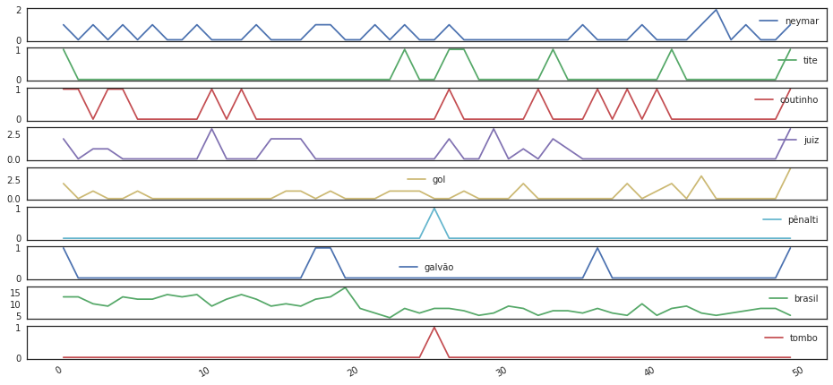

```python
rcParams['figure.figsize'] = 16, 8

pd.DataFrame(
    {name: localizar_palavra(name.lower(), tweets_spacy)
     for name in ['neymar', 'tite', 'coutinho', 'juiz', 'gol', 'pênalti', 'galvão', 'brasil', 'tombo']}
).plot(subplots=True)
plt.show()
```

### > O que será que aconteceu com o pico da palavra "Neymar" *(a.k.a., Neymala)?

### NÃO. Ele não estava caindo pelo incrível que pareça, isso aconteceu em todos os outros picos menores anteriores.

[figure not shown]

### Foi o gol mesmo, galere.

[figure not shown]

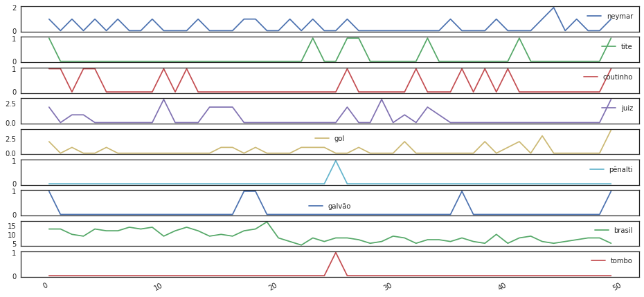

```python
rcParams['figure.figsize'] = 16, 8

pd.DataFrame(
    {name: localizar_palavra(name.lower(), tweets_spacy)
     for name in ['neymar', 'tite', 'coutinho', 'juiz', 'gol', 'pênalti', 'galvão', 'brasil', 'tombo']}
).plot(subplots=True)
plt.show()
```

### > E esse pico intermediário do Tite? #reiTite

## Cêis manjam necas, caras.

### Mestre Adenor estava apenas brincando... #vaicurintia

[figure not shown]

## 6. Reconhecimento de Entidades *(NER)*

Você também pode acessar [informações de NER](https://spacy.io/usage/linguistic-features#named-entities) pelo *doc.sents*.

Vamos listar as entidades reconhecidas nos *tweets*.

```python
set([w.label_ for w in tweets_spacy.ents])
```

```
{'LOC', 'MISC', 'ORG', 'PER'}
```

O diferencial do spaCy é que, quando ele não possui anotações similares em seu *córpus*, ele utiliza um modelo treinado com base na [Wikipedia](https://spacy.io/usage/linguistic-features#named-entities) com as seguintes características genéricas:

- **PER**: nomes de pessoas e famílias;
- **LOC**: nome de localizações geográficas (*e.g.,* cidades, países, montanhas, etc);
- **ORG**: nomes de organizações corporativas, governamentais, etc;
- **MISC**: entidades diversas (*e.g.,* eventos, nacionalidades, produtos, peças de arte, etc).

Tem um [artigo disponível](https://www.sciencedirect.com/science/article/pii/S0004370212000276) para quem quiser entender como este modelo foi construído.

Vamos listar o que foi identificado como uma localização (**LOC**).

```python
[ent for ent in tweets_spacy.ents if ent.label_ == 'LOC']
```

```
[Brasil,
 AO,
 Brasil,
 Costa Rica,
                                                                                                         @vishethata,
 RT,
 Brasil,
                                                                                                             ,
 ,
 Brasil,
                                                                                                                                         ,
 RT @jurandirfilho,
 Brasil,
 BRASIL,
                                                                                                                                     ,
 Brasil,
 BRASIL,
 Brasil,
 Brasil,
 BRASIL,
 Brasil,
 Brasil,
 Vamos Brasil,
 Brasil,
 BRASIL,
 Brasil,
 Opinião,
 Brasil,
 BRASIL,
 Brasil,
 Brasil,
 Brasil,
 Brasil,
 Brasil,
 Brasil,
 Brasil,
 Costa Rica,
 Futmais,
 Brasil,
 Brasil,
```

[output cut: 284 more lines]

```
 Brasil,
 Brasil,
 MESSI TCHAU,
 MESSI TCHAU,
 Brasil,
 ,
 Brasil,
                                                             ,
 RT,
 Lembrando,
 Brasil Ganhou,
 Brasil.\nFoi,
 Brasil,
 Ontem,
 RT @futmemes]
```

Vamos ver quais sentenças possuem **"Costa Rica"** rotulada como **LOC**.

```python
locs = [ent for ent in tweets_spacy.ents if ent.label_ == 'LOC' and ent.string.strip() == 'Costa Rica']
[ent.sent for ent in locs]
```

```
[Brasil x Costa Rica https://t.co/3eILVTpdG6 via @YouTubeasd
 8                                                                                                        ,
 A partir de agora você acompanha Brasil x Costa Rica em tempo real,
 olha Brasil eh impossivel ser feliz acordando cedo entao faz valer a pena e ganha da Costa Rica,
 Brasil x Costa Rica,
 perdendo.\nNão acordei cedo pra isso, quero goleada na Costa Rica…,
 olha Brasil eh impossivel ser feliz acordando cedo entao faz valer a pena e ganha da Costa Rica,
 Brasil x Costa Rica https://t.co/0fCfsgV1ZN via @YouTube,
 Brasil x Costa Rica https://t.co/M4UbEyJdUy via @YouTube,
 Brasil x Costa Rica,
 Brasil x Costa Rica,
 x Costa Rica ⚽\n\n🔥🔥🔥 https://t.co/3UfgmYfjVM,
 torcida jaraguaense vibra com vitória do Brasil contra Costa Rica: https://t.co/cvY6aATmgW https://t.co/85hMuDCMnB,
 o time da Costa Rica tava… https://t.co/nUHxI1DbZG
 676184          ,
 x Costa Rica ⚽\n\n🔥🔥🔥 https://t.co/3UfgmYfjVM,
 Brasil x Costa Rica :]
```

Vamos procurar também por um nome próprio para testar.

```python
per = [ent for ent in tweets_spacy.ents if ent.label_ == 'PER' and ent.string.strip() == 'Coutinho']
[ent.sent for ent in per]
```

```
[Sempre que o Brasil precisa ele decide, tá jogando muito o menino Coutinho.,
 Coutinho é o melhor do Brasil!]
```

## 7. Visualizar Entidades

Uma das coisas mais legais do spaCy são as funcionalidades de visualização que ele fornece através do [**displacy**](https://spacy.io/usage/visualizers).

```python
from spacy import displacy
```

[figure not shown]

Vamos exibir os *tweets* com as entidades identificadas rotuladas.

Isso é feito através do método **render()** com a propriedade **style**:

```
style='ent'
```

Não esqueça de também setar a propriedade **jupyter** senão o spaCy tentará startar um novo serviço.

```python
displacy.render(tweets_spacy, style='ent', jupyter=True, options={'distance': 140})
```

0 RT PER @cleytu: pelo amor de deus brasil eu não acordei cedo pra ver vcs perdendo hein  
1 RT @infitywar MISC : HINO DO MISC BRASIL O MAIS LINDO DE TODOS FALO MISC COM TRANQUILIDADE MISC 2 VAMO BRASIL MISC PELA AMOR DE DEUS 3 MISC RT @uebrisei PER : qm acordou cedo só p vê o brasil jogar rt aí MISC 4 RT @SeriesBrasil PER : HINO NACIONAL MISC DO BRASIL https://t.co/0NrBjp3qW6  
5 RT @Emiiteuss MISC : Um medo? — Brasil LOC não ser HEXACAMPEÃO PER https://t.co/fXXaGkZhFr  
6 RT @SeriesBrasil: HINO NACIONAL DO BRASIL https://t.co/0NrBjp3qW6  
7 GLOBO AO LOC VIVO HD 22/06/2018 - Brasil LOC x Costa Rica LOC https://t.co/3eILVTpdG6 via @YouTubeasd  
8 Primeiramente, bom dia, segundamente, VAI BRASIL!!!! MISC !  
9 RT @citoucicero PER : É sexta-feira, amor.\nVai Brasil ORG caralho! https://t.co/7vCMR1Lffz  
10 @vishethata LOC tô garrado já aqui na tv, é nois brasil  
11 RT LOC @herhode: 8hrs da manhã e estão fazendo festa no brasil bicho, a gente merece esse hexa  
12 RT MISC @hmdoido: Por favor Brasil LOC eu não acordei cedo pra vê você me decepcionando trate de dar o hexa pra nois 13 MISC RT @gui_cabreira: Vamoooo Brasil MISC 🇧 🇷 14 MISC RT @musoverao MISC : olha brasil espero q n me decepcione pq n acordei cedo atoa n 15 MISC Que hino o hino do Brasil MISC 16 o processo é rapido é um olho no jogo do brasil e outro no lotte family concert pra assistir o bts e minhas bb  
17 RT PER @FlaOtimista: O HINO DO BRASIL MISC É MUITO LINDO 😍😍😍😍😍 😍 MISC 18 MOSTRA A TUA FORÇA BRASIL MISC 19 RT @tweettorcidas: PER VAMOS BRASIL MISC 🇧 🇷 MISC 🇧 🇷 MISC 🇧 🇷 MISC  
20 RT PER @cleytu: VAMO BRASIL\nO HEXA MISC VEM #COPA2018 https://t.co/sBogpV2LXM  
21 VAMO ORG BRASIL SIL SIL ORG faça valer a pena eu te acordado cedo  
22 LOC VAAAAI BRASIL MISC # Copa2018 https://t.co/IwGAdc6LK7 ORG LOC 23 PER VAI BRASIL!! MISC ! 🇧 🇷 MISC #copa2018  
24 Assistindo PER o jogo do Brasil LOC em 4 K MISC 25 Brasil - Tosta Rica ORG 26 RT PER @SeriesBrasil: HINO NACIONAL MISC DO BRASIL https://t.co/0NrBjp3qW6  
27 LOC PÁTRIA ORG AMADA BRASIL 28 MISC QUE DEUS NOS ABENÇOE ORG E NOS PROTEJA! ORG VAMO BRASIL!!! MISC !  
29 RT ORG @InfosFuteboI: VAMO BRASIL! MISC 🙌 https://t.co/cfbyYbLxWA  
30 RT @jurandirfilho LOC : Acordando cedo pra ir pro trabalho / Acordando PER cedo pra ver o jogo do Brasil LOC # BRA ORG # BrasilGanha ORG https://t.co/tVQRTnj3zC  
31 VAI BRASIL LOC 🇧 🇷 MISC 32 LOC MOSTRA TUA FORÇA BRASIL ORG  
33 Pelo amor de Deus @brasil MISC não me mate do coração hoje, amém 34 MISC Brasil LOC não pode perder  
35 Bora PER acordar q vai começar a bagaça... Ganha PER isso ai plm BRASIL LOC # WorldCup MISC 36 Tudo bem torcer pro Brasil LOC , mas isso lá é hora de soltar fogos, meu anjo? NÃO ASSUSTA OS DOGUINHOS MISC , CARAMBA 37 MISC brasil um sonho intenso um raio vívido CONTINUA MISC de amor e de esperança à terra desce #brasilganha  
38 Congresso brasileiro MISC saqueia seu próprio país, diz geóloga da Petrobras https://t.co/ggjvioMtyP 39 MISC eu: hexa is real\n\n*brasil começa a jogar*\n\neu MISC : ah n mano num vai dar hexa ess…

## 8. Etiquetas Linguísticas *(Part-of-Speech Tagging)*

Talvez você já tenha ouvido falar sobre isso em sua abreviação **PoS**.

#### Atualmente:

### - O estado-da-arte para identificação de etiquetas de PoS no PennTree Bank (*córpus* em inglês bem famoso) chega a 97.3%$^{1}$

### - Estudos ainda mais recentes dizem ser possível atingir uma acurácia ainda maior com melhorias de taxonomias nos recursos linguísticos$^{2} $

Muita gente faz um monte de coisa de NLP legal, mas não aproveita os benefícios de **recursos linguísticos**.

Por exemplo: **contexto**.

Será que saber que "Neymar" é um **PROPN** e o **sujeito** da frase não te ajuda a construir diálogos em seu *chatbot*? E saber os **ADJ** da sentença relacionados à ele?

### > Não entendeu as abreviações?

## Calma, meu jóvi.

[figure not shown]

A lista das etiquetas do spaCy está [aqui](https://github.com/explosion/spacy/blob/master/spacy/lang/pt/tag_map.py) e, apesar de não fornecerem descrições, tem variações bem próximas [às etiquetas do PennTree Bank](https://catalog.ldc.upenn.edu/docs/LDC99T42/tagguid1.pdf).

$^{1}$ [Adding Context Information to Part Of Speech: Tagging for Dialogues](https://hrilab.tufts.edu/publications/kubleretal10tlt.pdf), Sandra Kübler, Matthias Scheutz, Eric Baucom, Ross Israe; Indiana University  
$^{2}$ [Part-of-Speech Tagging from 97% to 100%: Is It Time for Some Linguistics?](https://nlp.stanford.edu/pubs/CICLing2011-manning-tagging.pdf), Christopher D. Manning, Stanford University

### Vamos listar as etiquetas encontradas nos *tweets*.

```python
pos_dict = {w.pos: w.pos_ for w in tweets_spacy}
pos_dict
```

```
{89: 'DET',
 102: 'SPACE',
 99: 'VERB',
 95: 'PROPN',
 96: 'PUNCT',
 91: 'NOUN',
 83: 'ADJ',
 84: 'ADP',
 94: 'PRON',
 85: 'ADV',
 86: 'AUX',
 92: 'NUM',
 88: 'CCONJ',
 90: 'INTJ',
 98: 'SYM',
 100: 'X',
 97: 'SCONJ',
 93: 'PART'}
```

Vamos plotar a frequência de cada etiqueta linguística.

```python
tweets_pos = pd.Series(tweets_spacy.count_by(spacy.attrs.POS))/len(tweets_spacy)
```

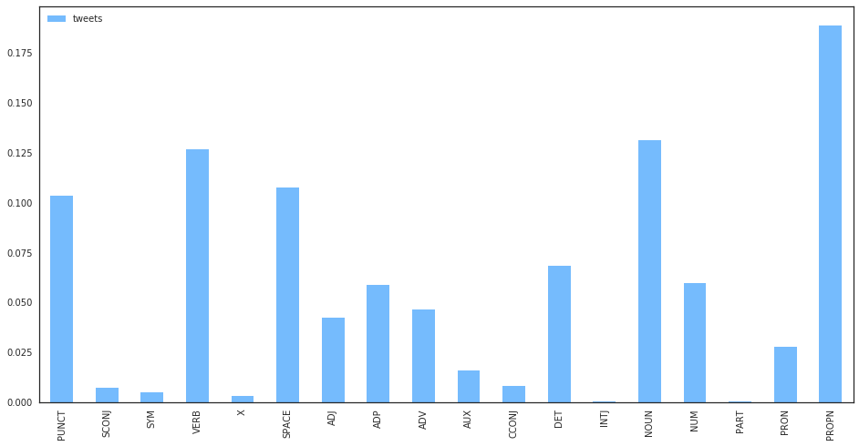

```python
rcParams['figure.figsize'] = 16, 8
df = pd.DataFrame([tweets_pos], index=['tweets'])
df.columns = [pos_dict[column] for column in df.columns]
df.T.plot(kind='bar', color='xkcd:sky blue')
plt.show()
```

Também podemos consultar quais os **adjetivos** mais comuns.

```python
from collections import Counter
```

Vamos ver o que foi rotulado como **PROPN**, a etiqueta com mais frequência.

```python
tweet_propn = [w for w in tweets_spacy if w.pos_ == 'PROPN']
Counter([w.string.strip() for w in tweet_propn]).most_common(10)
```

```
[('RT', 285),
 ('Brasil', 210),
 ('BRASIL', 116),
 ('Costa', 34),
 ('#', 34),
 ('💛', 34),
 ('VAMO', 21),
 ('Rica', 20),
 ('QUE', 18),
 ('SIL', 14)]
```

Podemos também consultar os **adjetivos** mais frequentes nos *tweets*.

```python
tweet_adjs = [w for w in tweets_spacy if w.pos_ == 'ADJ']
Counter([w.string.strip() for w in tweet_adjs]).most_common(10)
```

```
[('brasil', 46),
 ('juiz', 21),
 ('kkk\\n\\nA', 10),
 ('apita', 10),
 ('brasileiro', 9),
 ('único', 9),
 ('22/06/2018', 8),
 ('https://t.co/BmEFfiJL7Y', 8),
 ('HEXA', 6),
 ('melhor', 6)]
```

Ou ou **verbos** mais comuns.

```python
tweet_verb = [w for w in tweets_spacy if w.pos_ == 'VERB']
Counter([w.string.strip() for w in tweet_verb]).most_common(10)
```

```
[('🇧', 94),
 ('💚', 43),
 ('é', 42),
 ('RT', 32),
 ('ganhou', 23),
 ('eh', 21),
 ('É', 17),
 ('ganhar', 17),
 ('faz', 16),
 ('acordei', 15)]
```

Vamos descobrir o que foi rotulado como **X**.

```python
tweet_x = [w for w in tweets_spacy if w.pos_ == 'X']
Counter([w.string.strip() for w in tweet_x]).most_common(10)
```

```
[('🇧', 82),
 ('jogar', 74),
 ('ganhar', 70),
 ('acordar', 49),
 ('ceder', 37),
 ('apitar', 33),
 ('ficar', 28),
 ('💚', 26),
 ('torcer', 21),
 ('copar', 21)]
```

Também podemos buscar por **sentenças** ao invés de **palavras**.

```python
Counter([w.string.strip() for w in tweets_spacy.ents if w.label_ == 'PER']).most_common(10)
```

```
[('RT', 94),
 ('', 14),
 ('🇷', 8),
 ('RT @whindersson', 7),
 ('RT @_mlkclaudio', 5),
 ('RT @SeriesBrasil', 4),
 ('Firmino', 3),
 ('Tite', 3),
 ('🇷 \\n\\nBRASIL', 3),
 ('RT @uebrisei', 2)]
```

Uma das técnicas mais importantes de NLP, apesar de não tão conhecida, é a análise e processamento de **árvores sintáticas**.

## > JESUS, O QUE É ISSO?!

[figure not shown]

Vamos utilizar uma sentença como exemplo.

### ATENÇÃO: não esqueça de adicionar o caracter "u" antes da frase para identificá-la como unicode e ser aceita como entrada pelo método nlp() do spaCy!

```python
parsetree_sent = nlp(u' Não aguento mais essa aula, eu nunca quiser aprender isso na vida. A Rayssa é chata e a aula está ruim')
```

```python
{w.pos: w.pos_ for w in tweets_spacy}
```

```
{89: 'DET',
 102: 'SPACE',
 99: 'VERB',
 95: 'PROPN',
 96: 'PUNCT',
 91: 'NOUN',
 83: 'ADJ',
 84: 'ADP',
 94: 'PRON',
 85: 'ADV',
 86: 'AUX',
 92: 'NUM',
 88: 'CCONJ',
 90: 'INTJ',
 98: 'SYM',
 100: 'X',
 97: 'SCONJ',
 93: 'PART'}
```

### > Qual o **PROPN**?

*"Não aguento mais essa aula, eu nunca quiser aprender isso na vida. A Rayssa é chata e a aula está ruim"*

```python
parsetree_propn = [w for w in parsetree_sent if w.pos_ == 'PROPN']
Counter([w.string.strip() for w in parsetree_propn])
```

```
Counter({'Rayssa': 1})
```

### > Quais os **NOUN's**?

*"Não aguento mais essa aula, eu nunca quiser aprender isso na vida. A Rayssa é chata e a aula está ruim"*

```python
parsetree_noun = [w for w in parsetree_sent if w.pos_ == 'NOUN']
Counter([w.string.strip() for w in parsetree_noun])
```

```
Counter({'aula': 2, 'vida': 1})
```

### > Quais os **ADJ's**?

*"Não aguento mais essa aula, eu nunca quiser aprender isso na vida. A Rayssa é chata e a aula está ruim"*

```python
parsetree_adj = [w for w in parsetree_sent if w.pos_ == 'ADJ']
Counter([w.string.strip() for w in parsetree_adj])
```

```
Counter({'chata': 1, 'ruim': 1})
```

### > Quais os **VB's**?

*"Não aguento mais essa aula, eu nunca quiser aprender isso na vida. A Rayssa é chata e a aula está ruim"*

```python
parsetree_vb = [w for w in parsetree_sent if w.pos_ == 'VERB']
Counter([w.string.strip() for w in parsetree_vb])
```

```
Counter({'aguento': 1, 'quiser': 1, 'aprender': 1, 'é': 1, 'está': 1})
```

### > Quais os **DET's**?

*"Não aguento mais essa aula, eu nunca quiser aprender isso na vida. A Rayssa é chata e a aula está ruim"*

```python
parsetree_det = [w for w in parsetree_sent if w.pos_ == 'DET']
Counter([w.string.strip() for w in parsetree_det])
```

```
Counter({'essa': 1, 'na': 1, 'A': 1, 'a': 1})
```

### > Quais os **ADV's**?

*"Não aguento mais essa aula, eu nunca quiser aprender isso na vida. A Rayssa é chata e a aula está ruim"*

```python
parsetree_conj = [w for w in parsetree_sent if w.pos_ == 'ADV']
Counter([w.string.strip() for w in parsetree_conj])
```

```
Counter({'Não': 1, 'mais': 1, 'nunca': 1})
```

### > Quais os **PRON's**?

*"Não aguento mais essa aula, eu nunca quiser aprender isso na vida. A Rayssa é chata e a aula está ruim"*

```python
parsetree_conj = [w for w in parsetree_sent if w.pos_ == 'PRON']
Counter([w.string.strip() for w in parsetree_conj])
```

```
Counter({'eu': 1, 'isso': 1})
```

### > Quais os **CCONJ's**?

*"Não aguento mais essa aula, eu nunca quiser aprender isso na vida. A Rayssa é chata e a aula está ruim"*

```python
parsetree_conj = [w for w in parsetree_sent if w.pos_ == 'CCONJ']
Counter([w.string.strip() for w in parsetree_conj])
```

```
Counter({'e': 1})
```

### > Quais as **PUNCT's**?

*"Não aguento mais essa aula, eu nunca quiser aprender isso na vida. A Rayssa é chata e a aula está ruim"*

```python
parsetree_conj = [w for w in parsetree_sent if w.pos_ == 'PUNCT']
Counter([w.string.strip() for w in parsetree_conj])
```

```
Counter({',': 1, '.': 1})
```

### > Quais os **SPACE's**?

*"Não aguento mais essa aula, eu nunca quiser aprender isso na vida. A Rayssa é chata e a aula está ruim"*

```python
parsetree_conj = [w for w in parsetree_sent if w.pos_ == 'SPACE']
Counter([w.string.strip() for w in parsetree_conj])
```

```
Counter({'': 1})
```

# Todas as palavras estão ligadas

Você estudou **sintaxe** nas aulas de Língua Portuguesa na escola, certo? *(diz que sim, pfv)*

Então sabe que todas as palavras estão ligadas e você consegue dizer quais são as ligações, mesmo que não saiba dizer a **semântica** das palavras.

## > Você vai precisar relembrar suas aulas e estudar a linguística do Português!

Eu não tenho vergonha de assumir que tenho **três** livros de Língua Portuguese de ensino médio.

[figure not shown]

# Árvores Sintáticas

A técnica que mencionei nada mais é do que uma representação das etiquetas de PoS e as ligações entre as palavras.

Novamente, o spaCy é **muito(!) legal** e fornece uma visualização pronta **(e bonita)** para que você não precise construir na mão. Ao contrário do NLTK que printa uma árvore com caracteres, não imagens.

**ACREDITE**: *é **muito(!)** trabalhoso fazer isso na mão!*

Isso também é feito através do método **render()**, porém com a propriedade **style** setada como:

```
style='dep'
```

```python
displacy.render(parsetree_sent, style='dep', jupyter=True)
```

[figure not shown]

Você pode ajustar algumas opções também:

```python
options = {'compact': True, 'color': 'white', 'bg':'lightblue'}
```

```python
displacy.render(parsetree_sent, style='dep', jupyter=True, options=options)
```

[figure not shown]

# Pausa!

[figure not shown]

# ...voltando às sentenças

### Vamos ver o que a galerinha andou falando do Neymar.

### *#neymarCaiuPorAquiTambém #neymarJáCaiu5VezesNestaAula*

[figure not shown]

```python
neymar_sents = [sent for sent in tweets_spacy.sents if 'neymar' in sent.string.lower()]
```

```python
neymar_sents
```

```
[RT @neymarjr: VAMO,
 Brasil, \nboa tarde Rússia.\n@neymarjr dormiu bem, meu anjão?,
 Brasil
 233            RT @euteamoneymarj:,
 vai ser lindo amanha o 2x0 pro brasil com um gol do coutinho e outro do neymar
 676126         RT @ryanbrumcitou:,
 brasil ganhou\ngol do coutinho e neymar\ntite dando cambalhota\nbrasileiro bebendo cedo\nhexou\nsextou
 676135                                                                       ,
 Neymar xingando vc, chato pra c.... que só sabe falar mal https://t.co/fwEZXdEVeQ
 676136                               RT @pedrohales: brasileiros:,
 vai ser lindo amanha o 2x0 pro brasil com um gol do coutinho e outro do neymar
 676147           RT @slowtaehyung:,
 O Brasil sempre vai estar contigo, você é um monstro NEYMAR!!,
 Neymar…,
 RT @gordaopvcs: Melhor jogador do Brasil / quem ganha os créditos é o Neymar https://t.co/GTt9rSmRQM,
 Vão se fuder, Neymar é pica e vai trazer o hexa junto com o resto da seleção toda do Brasil, porem, infelizmente o cara e…,
 676203            Mas como eu disse antes, enquanto todo mundo continuar tratando o Neymar como "o time", o Brasil nunca vai vencer e… https://t.co/d1kiFubE8h
 676204        ,
 “vai lá torce pro brasil dnv, o neymar não te iludiu bastante” https://t.co/VTC0tHim8M
 676216                                                                                                                       ,
 Ésto es Brasil, ésto es Neymar Jr. 🇧,
 É O NEYMAR,
 Tite caindo\nNeymar poli…,
 Até o juiz não acredita mais nas quedas do Neymar...,
 do Coutinho aos 46\n\n- Gol do Neymar aos 52\n  \n-52-46= 6\n\nO Hexa é real, vai Brasil,
 676301                                           @neymarjr,
 \n- Gol do Coutinho aos 46'\n- Gol do Neymar aos 52'\n\n* 52-46 = 6\n\nO HEXA,
 "o Brasil só não tem Neymar" \nNem a Argentina só não tem Messi, e vcs só bota a culpa nele
 676307                                                                      ,
 O Brasil que eu quero é um Brasil sem o Neymar,
 vai ser lindo amanha o 2x0 pro brasil com um gol do coutinho e outro do neymar
 676316                                                     RT,
 Eu gosto do Neymar.,
 Tite caindo\nNeymar poli…,
 brasil ganhou\ngol do coutinho e neymar\ntite dando cambalhota\nbrasileiro bebendo cedo\nhexou\nsextou
 676371            RT @FCamposoficial: Firmino e Doulgas Costa entraram muito bem no jogo e podem ganhar titularidade.]
```

Você também pode printar a árvore sintática **bruta** apenas com caracteres (beijo, NLTK)

```python
for word in neymar_sents[2]:
    print(word, word.tag_, word.pos_)
```

```
Brasil PROP|M|S|@N< PROPN

  SPACE
233 <card>|NUM|F|P|@>N NUM
            _SP SPACE
RT PROP|M|S|@<ACC PROPN
@euteamoneymarj <card>|NUM|M|P|@<ACC NUM
: PU|@PU PUNCT
```

Você também pode consultar **a raiz e os nós** de uma árvore sintática

```python
list(neymar_sents[3].root.children)
```

```
[vai, ser, amanha, pro, @ryanbrumcitou, :]
```

Vemos ver todos os nós de cada palavra:

```python
for word in neymar_sents[3]:
    print(word, ': ', str(list(word.children)))
```

```
vai :  []
ser :  []
lindo :  [vai, ser, amanha, pro, @ryanbrumcitou, :]
amanha :  []
o :  []
2x0 :  []
pro :  [o, 2x0, brasil, gol]
brasil :  []
com :  []
um :  []
gol :  [com, um, coutinho, neymar]
do :  []
coutinho :  [do, outro]
e :  []
outro :  [e]
do :  []
neymar :  [do,
, RT]

 :  []
676126 :  [        ]
         :  []
RT :  [676126]
@ryanbrumcitou :  []
: :  []
```

### E quais **ADJ** descrevem o Neymala?

```python
for sent in neymar_sents:
    for word in sent:
        for child in word.children:
            if child.pos_ == 'ADJ':
                print(child)
```

```
2x0
brasil
2x0
brasil
Melhor
@gordaopvcs
fuder
brasil
real
6\n\nO
2x0
brasil
@FCamposoficial
Firmino
```

```python
tite_sents = []
for sent in tweets_spacy.sents:
    if 'tite' in sent.string.lower():
        tite_sents.append(sent)
```

### Vamos ver o que foi falado sobre nosso **Mestre Adenor**.

[figure not shown]

```python
tite_sents = [sent for sent in tweets_spacy.sents if 'tite' in sent.string.lower()]
```

```python
tite_sents
```

```
[brasil ganhou\ngol do coutinho e neymar\ntite dando cambalhota\nbrasileiro bebendo cedo\nhexou\nsextou
 676135                                                                       ,
 O TITE PENSOU QUE TAVA NO BRASIL,
 A RETRANCA DO ADVERSARIO\n\nTITE OLHA,
 Tite caindo\nNeymar poli…,
 sextou \nbrasil ganho\ntá liberado usa droga ate cai no chao igual o tite
 676274                                                                  ,
 TITE ÍCONE.,
 Tirei o tombo do Tite no primeiro gol!,
 sextou \nbrasil ganho\ntá liberado usa droga ate cai no chao igual o tite
 676325                                                                           ,
 Tite caindo\nNeymar poli…,
 brasil ganhou\ngol do coutinho e neymar\ntite dando cambalhota\nbrasileiro bebendo cedo\nhexou\nsextou
 676371            RT @FCamposoficial: Firmino e Doulgas Costa entraram muito bem no jogo e podem ganhar titularidade.]
```

```python
for word in tite_sents[2]:
    print(word, word.tag_, word.pos_)
```

```
A <artd>|ART|F|S|@>N DET
RETRANCA PROP|F|S|@SUBJ> PROPN
DO PROP|@N< PROPN
ADVERSARIO\n\nTITE PU|@PU PUNCT
OLHA PROPN PROPN
```

### E sobre Coutinho? #nossoSalvador #quemÉNeymar

[figure not shown]

```python
coutinho_sents = [sent for sent in tweets_spacy.sents if 'coutinho' in sent.string.lower()]
```

```python
coutinho_sents
```

```
[Dim Dim Dim traz o #HEXA pra miiim @Phil_Coutinho!!!,
 vai ser lindo amanha o 2x0 pro brasil com um gol do coutinho e outro do neymar
 676126         RT @ryanbrumcitou:,
 brasil ganhou\ngol do coutinho e neymar\ntite dando cambalhota\nbrasileiro bebendo cedo\nhexou\nsextou
 676135                                                                       ,
 vai ser lindo amanha o 2x0 pro brasil com um gol do coutinho e outro do neymar
 676147           RT @slowtaehyung:,
 RT @newscolina: Philippe Coutinho,
 Philippe Coutinho foi eleito o melhor jogador da partida entre Brasil e Costa Rica!,
 O Philipe Coutinho foi de novo eleito o melhor jogador da partida!,
 👏\n\nParabéns, @Phil_Coutinho , eleito o @Budweiser_BR #ManoftheMatch do #BRACRC!,
 Sempre que o Brasil precisa ele decide, tá jogando muito o menino Coutinho.,
 do Coutinho aos 46\n\n- Gol do Neymar aos 52\n  \n-52-46= 6\n\nO Hexa é real, vai Brasil,
 \n- Gol do Coutinho aos 46'\n- Gol do Neymar aos 52'\n\n* 52-46 = 6\n\nO HEXA,
 vai ser lindo amanha o 2x0 pro brasil com um gol do coutinho e outro do neymar
 676316                                                     RT,
 Coutinho é o melhor do Brasil!,
 brasil ganhou\ngol do coutinho e neymar\ntite dando cambalhota\nbrasileiro bebendo cedo\nhexou\nsextou
 676371            RT @FCamposoficial: Firmino e Doulgas Costa entraram muito bem no jogo e podem ganhar titularidade.]
```

### E quais **ADJ** descrevem nosso rei?

```python
for sent in coutinho_sents:
    for word in sent:
        for child in word.children:
            if child.pos_ == 'ADJ':
                print(child)
```

```
2x0
brasil
2x0
brasil
melhor
melhor
BRACRC
real
6\n\nO
2x0
brasil
@FCamposoficial
Firmino
```

## Vamos brincar com verbos e palavras

Este método vai buscar verbos (TOP20) relacionados à uma palavra informada.

```python
def verbs_characters(text, character):
    sents = [sent for sent in text.sents if character in sent.string]
    char_words = []
    for sent in sents:
        for word in sent:
            if character in word.string:
                char_words.append(word)
    char_verbs = []
    for word in char_words:
        for ancestor in word.ancestors:
            if ancestor.pos_.startswith('V'):
                char_verbs.append(ancestor.lemma_.strip())
    return Counter(char_verbs).most_common(20)
```

Vamos guardar algumas buscas:

```python
neymar_verbs = verbs_characters(tweets_spacy, 'Neymar')
neymar_verbs
```

```
[('xingar', 1),
 ('tratar', 1),
 ('vencer', 1),
 ('dizer', 1),
 ('acreditar', 1),
 ('ir', 1),
 ('ter', 1),
 ('gostar', 1)]
```

```python
coutinho_verbs = verbs_characters(tweets_spacy, 'Coutinho')
coutinho_verbs
```

```
[('eleito', 3), ('trazer', 1), ('jogar', 1), ('decidir', 1), ('ir', 1)]
```

```python
alisson_verbs = verbs_characters(tweets_spacy, 'Alisson')
alisson_verbs
```

```
[('pistola', 2)]
```

```python
juiz_verbs = verbs_characters(tweets_spacy, 'juiz')
juiz_verbs
```

```
[('apitar', 20), ('pedir', 1), ('pegar', 1), ('acreditar', 1), ('ajudar', 1)]
```

```python
gol_verbs = verbs_characters(tweets_spacy, 'gol')
gol_verbs
```

```
[('fazer', 15),
 ('meter', 4),
 ('lindar', 3),
 ('acordar', 2),
 ('cedo\\nhexou\\nsextou', 2),
 ('comprar', 1),
 ('matar', 1),
 ('dar', 1),
 ('querer', 1),
 ('feito', 1),
 ('Queremos', 1),
 ('acréscimo', 1),
 ('ir', 1),
 ('pegar', 1),
 ('tentar', 1),
 ('ser', 1),
 ('Tirei', 1),
 ('ver', 1),
 ('amo', 1)]
```

```python
brasil_verbs = verbs_characters(tweets_spacy, 'brasil')
brasil_verbs
```

```
[('ganhar', 30),
 ('acordar', 7),
 ('ver', 7),
 ('fazer', 6),
 ('RT', 5),
 ('mostrar', 4),
 ('cedo\\nhexou\\nsextou', 4),
 ('postar', 4),
 ('ir', 3),
 ('chorar', 3),
 ('lindar', 3),
 ('representar', 3),
 ('boicotar', 3),
 ('matar', 2),
 ('perder', 2),
 ('jogar', 2),
 ('acreditar', 2),
 ('ter', 2),
 ('teu', 2),
 ('dar', 2)]
```

Agora vamos plotar essas informações, a função abaixo apenas constrói um *dataframe* para facilitar.

```python
def verbs_matrix(verb_counts):
    return pd.Series({t[0]: t[1] for t in verb_counts})
```

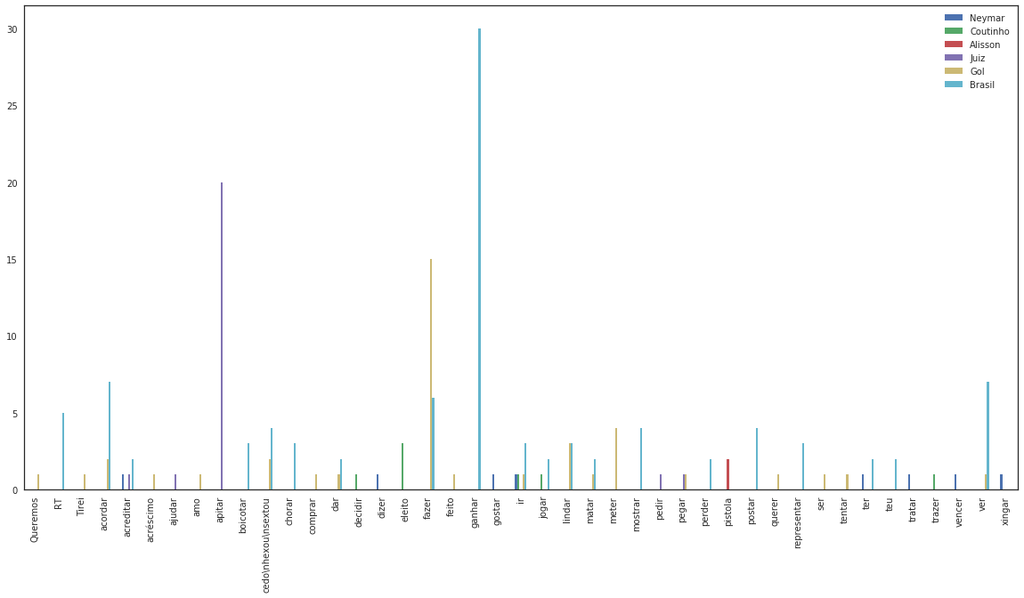

```python
verbs_df = pd.DataFrame({'Neymar': verbs_matrix(neymar_verbs),
                        'Coutinho': verbs_matrix(coutinho_verbs),
                        'Alisson': verbs_matrix(alisson_verbs),
                        'Juiz': verbs_matrix(juiz_verbs),
                        'Gol': verbs_matrix(gol_verbs),
                        'Brasil': verbs_matrix(brasil_verbs)}).fillna(0)
verbs_df.plot(kind='bar', figsize=(20,10))
plt.show()
```

## 9. Vetores de palavras *(word embeddings)*$^{1}$

### O que é?

O computador, em si, não interpreta textos, certo? Então como processar Língua Natural?

Precisamos transformar estes textos em **valores numéricos representativos.**

Existem diversas técnicas para isso, mas todas são formas de construir uma representação numérica para cada palavra em seu *córpus*. E, como em uma **sentença** temos diversas palavras, cada sentença vai possuir um **vetor** de valores numéricos para representar as palavras de uma sentença.

Mas como isso nos ajuda **na prática**?

#### Complete a seguinte frase:

[figure not shown]

#### Um bom modelo treinado deve ser capaz de extrair informações de conceitos e significados das palavras:

[figure not shown]

### Tipos de técnicas

1. *Bag of Words* (BoW)
2. BoW + TF-IDF
3. *Continuous Bag of Words* (CBOW)
4. *Skip-gram*
5. *Global Vectors* ([GloVe](https://nlp.stanford.edu/pubs/glove.pdf))

### Vamos focar em BoW + TF-IDF nesta aula por limitações de tempo, ok?

#### Quem quiser material sobre os demais é só me avisar!

[figure not shown]

O BoW tradicional nada mais é do que uma representação numérica de palavras em um vetor com valores binários: **presença** ou **ausência** de palavra em cada sentença, dadas todas as palavras de um *córpus*.

Apenas a existência ou não de uma palavra não se provou ser suficiente e, com o tempo, foi adotada a estratégia de **contar ocorrências** de palavras.

É o famoso **term-frequency** (TF)$^{2}$, onde a frequência de uma palavra \textbf{p} é calculada dividindo-se sua frequência pelo número total de palavras em um conjunto de documentos:

\begin{align} \label{math:tf} TF(p) = \frac{quantidade\ de\ \textbf{p}\ no\ documento}{total\ de\ palavras\ no\ documento} \end{align}

**Na prática?** Vamos supor que tenhamos três frases:

1. Eu amo chocolate
2. Ele gosta de dormir
3. Eu amo viajar

Nosso *córpus* é o conjunto de todas estas palavras:

\begin{equation*} \mathbf{X} = \begin{array}{cc} \\ \mathit{eu} \\ \mathit{amo} \\ \mathit{chocolate} \\ \mathit{ele} \\ \mathit{gosta} \\ \mathit{de} \\ \mathit{dormir} \\ \mathit{eu} \\ \mathit{amo} \\ \mathit{viajar} \\ \end{array} \begin{bmatrix} \begin{array}{c} & \mathit{eu} & \mathit{amo} & \mathit{chocolate} & \mathit{ele} & \mathit{gosta} & \mathit{de} & \mathit{dormir} & \mathit{eu} & \mathit{amo} & \mathit{viajar}\\ & 0 & 2 & 0 & 0 & 0 & 0 & 0 & 0 & 0 & 0 \\ & 2 & 0 & 1 & 0 & 0 & 0 & 0 & 0 & 0 & 1 \\ & 0 & 1 & 0 & 0 & 0 & 0 & 0 & 0 & 0 & 0 \\ & 0 & 0 & 0 & 0 & 1 & 0 & 0 & 0 & 0 & 0 \\ & 0 & 0 & 0 & 1 & 0 & 1 & 0 & 0 & 0 & 0 \\ & 0 & 0 & 0 & 0 & 1 & 0 & 1 & 0 & 0 & 0 \\ & 0 & 0 & 0 & 0 & 0 & 1 & 0 & 0 & 0 & 0 \\ & 0 & 0 & 0 & 0 & 0 & 0 & 0 & 0 & 0 & 0 \\ & 0 & 0 & 1 & 0 & 0 & 0 & 0 & 0 & 0 & 1 \\ & 0 & 1 & 0 & 0 & 0 & 0 & 0 & 0 & 1 & 0 \\ \end{array} \end{bmatrix} \end{equation*}

Porém, as palavras mais frequentes não são necessariamente as mais **relevantes**.

Considere a palavra \textit{"que"} da língua Portuguesa. É uma das palavras mais frequentes no vocabulário, porém, não tem relevância **semântica** na maioria dos casos. Apenas a frequência de uma palavra não é suficiente para calcular sua relevância.

### E as palavras MENOS utilizadas?

Maior probabilidade de terem um significado semântico dentro de um contexto de vários documentos!

E este é o famoso **inverse document frequency** (IDF)$^{3}$:

\begin{align} \label{math:idf} IDF(p) = log_e(\frac{quantidade\ de\ documentos}{total\ de\ documentos\ com\ \textbf{p}}) \end{align}

$^{1}$[Modern_NLP_in_Python](http://nbviewer.jupyter.org/github/skipgram/modern-nlp-in-python/blob/master/executable/Modern_NLP_in_Python.ipynb#topic=0&lambda=0.6&term=)* $^{2}$[Term frequency and weighting](https://nlp.stanford.edu/IR-book/html/htmledition/term-frequency-and-weighting-1.html)* $^{3}$[Inverse document frequency](https://nlp.stanford.edu/IR-book/html/htmledition/inverse-document-frequency-1.html)*

# Similaridade de palavras

Uma coisa legal que conseguimos fazer através destes vetores de palavras é calcular a **similaridade semântica** entre palavras.

Vamos testar algumas palavras.

```python
tite, neymar, gol, brasil, coutinho, tombo = nlp('tite'), nlp('neymar'), nlp('gol'), nlp('brasil'), nlp('coutinho'), \
                                             nlp('tombo')
```

Qual a similaridade entre as palavras "Neymar" e "Tite"?

```python
tite.similarity(neymar)
```

```
0.5722952414078317
```

Qual a similaridade entre as palavras "Neymar" e "gol"?

```python
neymar.similarity(gol)
```

```
0.696521366257805
```

Qual a similaridade entre as palavras "Coutinho" e "gol"?

```python
coutinho.similarity(gol)
```

```
0.7618868286901809
```

Qual a similaridade entre as palavras "Tite" e "Brasil"?

```python
tite.similarity(brasil)
```

```
0.5974372945465648
```

Qual a similaridade entre as palavras "Tite" e "tombo"? (ops!)

```python
tite.similarity(tombo)
```

```
0.6594423259096553
```

Qual a similaridade entre as palavras "Neymar" e "tombo"?

```python
neymar.similarity(tombo)
```

```
0.42490662663801393
```

#### Um exemplo mais realista sobre a aplicação de similaridade semântica.

```python
nlp('rayssa').similarity(nlp('larissa'))
```

```
0.7786461143691964
```

## Vamos ver os vetores de NOUN's dos *tweets*

Primeiro vamos pegar os NOUN's, em si.

```python
tweets_nouns = [word for word in tweets_spacy if word.pos_.startswith('N')][:150]
```

```python
tweets_nouns
```

```
[pelo,
 deus,
 hein,
 1,
 DO,
 MAIS,
 2,
 3,
 brasil,
 4,
 HINO,
 DO,
 https://t.co/0NrBjp3qW6,
 5,
 medo,
 https://t.co/fXXaGkZhFr,
 6,
 HINO,
 DO,
 https://t.co/0NrBjp3qW6,
 7,
 via,
 8,
 dia,
 9,
 @citoucicero,
 feira,
 caralho,
 https://t.co/7vCMR1Lffz,
 10,
 tv,
 11,
 8hrs,
 manhã,
 festa,
 bicho,
 gente,
 hexa,
 12,
 favor,
```

[output cut: 95 more lines]

```
 resultado,
 9,
 47,
 seleção,
 jogo,
 #,
 48,
 49,
 caminho,
 #,
 pla,
 50,
 51,
 cima,
 52]
```

Agora vamos mapear o vetor.

```python
tweets_noun_vecs = [word.vector for word in tweets_nouns if len(word)>2]
tweets_noun_labels = [word.string.strip() for word in tweets_nouns if len(word)>2]
```

Temos um vetor de 384 dimensões.

```python
tweets_noun_vecs[0].shape
```

```
(384,)
```

Vamos printar o vetor.

```python
tweets_noun_vecs
```

[output not shown]

[output cut: 7374 more lines]

[output not shown]

Um vetor com tantas dimensões é muito difícil de interpretar.

Vamos reduzir a dimensionalidade para conseguir plotar estas informações em **2D**.

O algoritmo utilizado é o [Latent Semantic Analysis (LSA)](https://nlp.stanford.edu/IR-book/html/htmledition/latent-semantic-indexing-1.html) do scikit-learn.

```python
from sklearn.decomposition import TruncatedSVD
```

```python
lsa = TruncatedSVD(n_components=2)
lsa_out = lsa.fit_transform(tweets_noun_vecs)
```

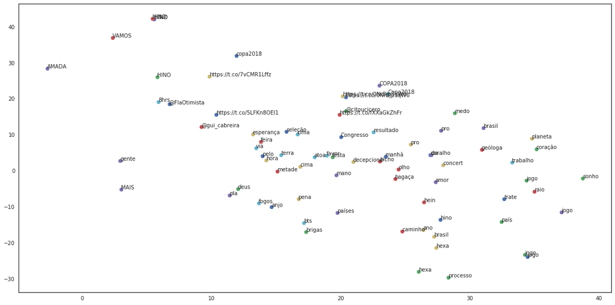

```python
fig, ax = plt.subplots(figsize=(20, 10))
xs, ys = lsa_out[:,0], lsa_out[:,1]
for i in range(len(xs)):
    plt.scatter(xs[i], ys[i])
    plt.annotate(tweets_noun_labels[i], (xs[i], ys[i]))
```

## 10. N-grams

### O que é?

Ao invés de considerar palavras individualmente (*unigram*), esta técnica consiste na análise de **conjuntos** de palavras em uma sentença, já que elas estão relacionadas entre si (premissa de [Markov](https://web.stanford.edu/~jurafsky/slp3/9.pdf))$^{1}$.

Comumente é utilizado **bi-gram**, **tri-gram**, **4-gram** e **5-gram** e, apesar de não ser suficiente já que as palavras de uma linguagem possuem relações "distantes" (*e.g.,* "que"), você vai conseguir ter muitos benefícios com sua utilização na grande maioria dos casos.

$^{1}$[Introduction to N-grams](https://web.stanford.edu/class/cs124/lec/languagemodeling2016.pdf)*

### Vamos construir ngrams para nossos *tweets*

Este método criar n-grams de qualquer **doc** spaCy a partir da quantidade **n** informada.

```python
def ngrams(doc, n):
    doc = [word for word in doc
           if word.is_alpha
           if not word.string.isupper()]
    return list(zip(*[doc[i:] for i in range(n)]))
```

```python
tweets_grams = set(ngrams(tweets_spacy, 3))
```

Vamos ver o resultado!

```python
tweets_grams
```

```
{(eu, acordei, cedo),
 (a, renovação, da),
 (em, cancer, sabe),
 (ser, lindo, amanha),
 (primeira, brasileiros, Vai),
 (Foi, engraçado, no),
 (Brasil, fazer, dois),
 (olê, olê, olê),
 (folga, pra, quem),
 (Jesus, meteu, gol),
 (ser, hexa, vocês),
 (brasil, oLHA, cedo),
 (acordou, cedo, só),
 (vou, acordar, jogo),
 (a, gente, fica),
 (pra, fazer, gol),
 (vai, lá, torce),
 (com, tudo, Brasil),
 (com, a, Costa),
 (faz, isso, cmg),
 (mal, brasileiros, vamos),
 (Já, tô, me),
 (a, pouco, tem),
 (trás, e, a),
 (tento, acreditar, mas),
 (não, vai, ser),
 (imploro, Vai, Brasil),
 (Brasil, se, não),
 (faz, isso, cmg),
 (depois, de, saindo),
 (dia, Brasil, Boa),
 (pra, ver, o),
 (brasil, e, outro),
 (copa, é, pq),
 (hora, que, eu),
 (Para, você, que),
 (Costa, Rica, Copa),
 (voltar, a, debochar),
 (eh, todo, mundo),
 (anos, que, o),
```

[output cut: 946 more lines]

```
 (atrai, o, que),
 (tempo, e, dizendo),
 (ja, perceberam, q),
 (caralho, na, av),
 (chorando, eu, te),
 (sexta, feira, jogo),
 (gente, fica, como),
 (light, is, coming),
 (mt, puta, acordando),
 (já, brigou, com),
 (isso, cmg, Brasil),
 (e, alemanha, com),
 (seg, vcs, ja),
 (pode, perder, Bora),
 ...}
```

## 11. Pré-processamento de textos

### O que é?

Antes de podermos analisar sentimentos dos *tweets*, temos que tratar os textos.

Existem atividades "padrões" para o pré-processamento, vamos falar de todos eles ainda hoje:

1. Limpeza do texto
2. Tokenização
3. *Stemming* ou *Lemmatisation*

#### > Vocês reparam a quantidade de ruídos?

- Pontuações
- Letras maiúsculas e minúsculas
- Caracteres especiais

Além disso, existem palavras que **não possuem valor semântico** (*e.g.,* "de", "para", "que", etc), ou seja, são desnecessárias em grande parte dos casos de análise textual.

Essas palavras são chamadas de **stopwords**.

## > Conseguem me dizer um caso onde não podemos eliminar nenhuma palavra?

# ...VALENDO!

[figure not shown]

# SIM, CONTEXTO!

[figure not shown]

$^{1}$[Introduction to N-grams](https://web.stanford.edu/class/cs124/lec/languagemodeling2016.pdf)*

## *Stopwords*

Como lidamos com *stopwords* então?

Listamos todas as palavras "desnecessárias" na mão?

## Não! #tksGod

Todas as ferramentas de NLP possuem listas de *stopwords* para diferentes idiomas.

### PORÉM!

Para nosso querido idioma, Português, as listas existentes não costumam ser suficientes.

É bem comum ajustar a lista com novas *stopwords*.

No spaCy é bem simples utilizar *stopwords* também.

```python
from spacy.lang.pt.stop_words import STOP_WORDS
```

Vamos dar uma olhada na lista.

```python
print(STOP_WORDS)
```

```
{'vem', 'todas', 'algo', 'até', 'boa', 'sabe', 'último', 'em', 'usar', 'nove', 'verdade', 'parece', 'sistema', 'vez', 'máximo', 'certeza', 'sempre', 'tempo', 'era', 'põe', 'já', 'como', 'estar', 'vos', 'vós', 'para', 'duas', 'quatro', 'estou', 'novo', 'usa', 'apoia', 'deverá', 'neste', 'vêm', 'porqu…
```

Algo que temos bem específico em nosso *dataset*, não chega nem a ser uma palavra, mas também precisamos como *stopwords*.

## "RT"!

Vamos adicionar este "termo" à lista de *stopwords*.

```python
STOP_WORDS.add("rt")
```

Vamos ver quais palavras de nosso *dataset* são *stopwords* configurando nosso próprio atributo **"is_stop"**.

```python
from spacy.tokens import Token
```

```python
stop_words_getter = lambda token: token.is_stop or token.lower_ in STOP_WORDS or token.lemma_ in STOP_WORDS
```

```python
Token.set_extension('is_stop', getter=stop_words_getter)
```

```python
for word in STOP_WORDS:
    lexeme = nlp.vocab[word]
    lexeme.is_stop = True
```

Vamos printar cada palavra e identificar se é ou não uma *stopword*.

```python
for token in tweets_spacy:
    print(token, token.lemma_, token._.is_stop)
```

```
0 0 False
                                                                                                                                                      False
RT RT True
@cleytu @cleytu False
: : False
pelo pelar True
amor amor False
de de True
deus deus False
brasil brasil False
eu eu True
não não True
acordei acordar False
cedo ceder True
pra pra False
ver ver True
vcs vcs False
perdendo perder False
hein hein False


 False
1 1 False
                                                                                                                                                                      False
RT RT True
@infitywar @infitywar False
: : False
HINO HINO False
DO DO True
BRASIL BRASIL False
O O False
MAIS MAIS True
LINDO LINDO False
DE DE True
TODOS TODOS True
FALO FALO False
COM COM True
TRANQUILIDADE TRANQUILIDADE False


```

[output cut: 10597 more lines]

```
🇷 🇷 False


 False
Name Name False
: : False
text text False
, , False
Length Length False
: : False
676375 676375 False
, , False
dtype dtype False
: : False
object object False
```

## *Stemming* e *Lemmatisation*$^{1}$

Muitas palavras possuem diferentes variações, principalmente em nosso idioma.

O verbo "estudar", por exemplo, pode ser utilizado em diferentes conjugações além da variação singular/plural:

- Estudo
- Estudei
- Estudaram
- Estudamos
- Etc.

#### Será que interpretar todas as palavras em todas as suas variações é o melhor cenário de NLP?

Não, né?

Justamente por isso existem técnicas para "normalizar" as palavras:

- *Stemming*: talvez a mais conhecida, é uma técnica responsável por reduzir uma palavra para sua **raiz gramatical**. Ou seja, independente de sua conjugação, a palavra estudar é sempre reduzida para **estud**. O *stemmer* mais conhecido é o de **Porter**. Essa técnica é a utilizada no [NLTK](http://www.nltk.org/howto/stem.html).
- *Lemmatisation*: ao invés de reduzir uma palavra par sua sua raiz gramatical, esta ténica consiste na redução para seu [**lema**](https://priberam.pt/dlpo/lema), ou seja, sua entrada de verbete em dicionários (*e.g.*, "estudei", "estudaram", "estudou", etc, ficariam sempre como **"estudar"**). Essa técnica é a utilizada pelo [spaCy](https://spacy.io/api/lemmatizer).

$^{1}$[Stemming and lemmatization](https://nlp.stanford.edu/IR-book/html/htmledition/stemming-and-lemmatization-1.html)*

Vamos ver como ficaria as palavras de nosso *córpus* após a *lemmetisation*.

```python
lemmas = [token.lemma_ for token in tweets_spacy if not token.is_stop ]
```

```python
lemmas = [lemma for lemma in lemmas if len(lemma)>2]
```

Vamos excluir "@" (menções) e "http" (links).

```python
lemmas = [lemma for lemma in lemmas if '@' not in lemma]
```

```python
lemmas = [lemma for lemma in lemmas if 'http' not in lemma]
```

Vamos ver como ficou.

```python
lemmas
```

```
['                                                                          ',
 'amor',
 'deus',
 'brasil',
 'acordar',
 'pra',
 'vcs',
 'perder',
 'hein',
 '                                                                                  ',
 'HINO',
 'BRASIL',
 'MAIS',
 'LINDO',
 'TODOS',
 'FALO',
 'COM',
 'TRANQUILIDADE',
 '                                                                                                                               ',
 'VAMO',
 'BRASIL',
 'PELA',
 'AMOR',
 'DEUS',
 '                                                                                                  ',
 'acordar',
 'ver',
 'brasil',
 'jogar',
 '                                                                                           ',
 'HINO',
 'NACIONAL',
 'BRASIL',
 '                                                                                ',
 'medo',
 'Brasil',
 'HEXACAMPEÃO',
 '                                                                                           ',
 'HINO',
 'NACIONAL',
```

[output cut: 946 more lines]

```
 '144',
 '                                                                        ',
 'Brasil',
 'exigir',
 'gol',
 'nao',
 'acordar',
 'atoa',
 '145',
 '                                                                                                                     ',
 'VAI',
 'BRASIL',
 'METE',
 'UNS',
 ...]
```

Vamos construir um *dataframe* com os tokens *lemmetizados*.

```python
lemmas_df = pd.DataFrame(lemmas, columns={'token'})
```

```python
lemmas_df['token'] = lemmas_df['token'].apply(lambda x: x.replace('\\n', ''))
```

O método abaixo normaliza (*lowercase*, tokenização, lemmetização) os *tweets*.

```python
def normalizar(comment, lowercase, remove_stopwords):
    if lowercase:
        comment = comment.lower()
    comment = nlp(comment)
    lemmatized = list()
    for word in comment:
        lemma = word.lemma_.strip()
        if lemma:
            if not remove_stopwords or (remove_stopwords and lemma not in STOP_WORDS):
                lemmatized.append(lemma)
    return " ".join(lemmatized)
```

```python
%%time
lemmas_df['token'] = lemmas_df['token'].apply(normalizar, lowercase=True, remove_stopwords=True)
```

```
CPU times: user 4min 50s, sys: 1h 2min 16s, total: 1h 7min 7s
Wall time: 1min 3s
```

Excluindo registros vazios.

```python
lemmas_df = lemmas_df.loc[lemmas_df['token'] != '']
```

Vamos ver o *dataframe*.

```python
lemmas_df.iloc[:10]
```

|  | token |
| --- | --- |
| 1 | amor |
| 2 | deus |
| 3 | brasil |
| 4 | acordar |
| 5 | pra |
| 6 | vcs |
| 7 | perder |
| 8 | hein |
| 10 | hino |
| 11 | brasil |

## *Wordcount* (TF)

Lembram que falamos que a forma mais antiga de vetorizar textos é a contagem de palavras (TF)?

É bem fácil fazer isso através de um **Counter()** do Python.

```python
wordcount = Counter(lemmas_df['token'])
```

Com ele conseguimos facilmente acessar as palavras mais comuns.

```python
wordcount.most_common(30)
```

```
[('brasil', 453),
 ('jogar', 78),
 ('ganhar', 66),
 ('pra', 57),
 ('acordar', 49),
 ('hexa', 44),
 ('costa', 42),
 ('o', 37),
 ('hino', 31),
 ('apitar', 31),
 ('brasileiro', 30),
 ('rico', 28),
 ('ficar', 28),
 ('torcer', 26),
 ('copar', 25),
 ('gol', 25),
 ('juiz', 25),
 ('gente', 20),
 ('pro', 20),
 ('mostrar', 18),
 ('neymar', 18),
 ('forçar', 16),
 ('país', 16),
 ('tava', 16),
 ('sil', 15),
 ('amar', 15),
 ('...', 15),
 ('mundo', 15),
 ('bolar', 15),
 ('brasilganha', 14)]
```

Vamos transformar o Counter() em um *dataframe*.

```python
words = pd.DataFrame.from_dict(wordcount, orient='index').reset_index()
```

```python
words.rename(columns={'index':'token'}, inplace=True)
```

```python
words.rename(columns={0:'count'}, inplace=True)
```

Vamos transformar as palavras em **docs** do spaCy para acessar seus atributos linguísticos.

```python
%%time
words['token'] = words['token'].apply(nlp)
```

```
CPU times: user 1min 28s, sys: 18min 48s, total: 20min 17s
Wall time: 19 s
```

```python
words.sort_values('count', ascending=False).iloc[:10]
```

[output not shown]

*(lembra da fórmula que vimos antes, né?)*

```python
words['freq'] = words['count'].apply(lambda x: x/len(words))
```

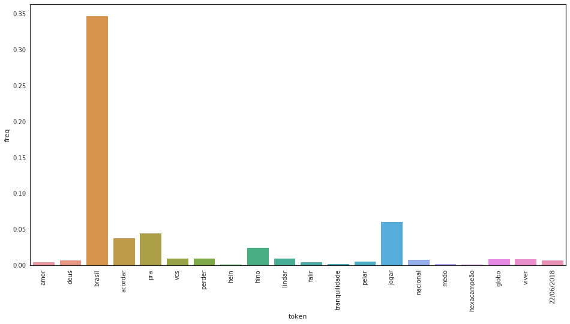

```python
sns.barplot(x=words.iloc[:20]['token'], y=words.iloc[:30]['freq'])
plt.xticks(rotation=90)
plt.show()
```

## Matrix de similaridade

Vamos aplicar o que já estudamos agora:

É legal fazer isso com o **doc** inteiro, mas cuidado com o tamanho dele.

Você vai conseguir plotar, mas a visualização vai ficar bem complicada!

```python
tmp_similaridade = words.iloc[:20]
```

```python
similaridades = [[word.similarity(other) for other in tmp_similaridade['token']] for word in tmp_similaridade['token']]
```

```python
labels = words.iloc[:20]['token']
```

```python
similaridades_df = pd.DataFrame(similaridades, columns=labels, index=labels)
```

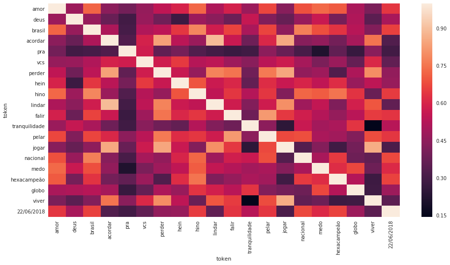

```python
rcParams['figure.figsize'] = 16, 8
sns.heatmap(similaridades_df)
plt.show()
```

## 12. Análise de Sentimentos$^{1}$$^{2}$

### O que é?

Antes de podermos analisar sentimentos dos *tweets*, temos que tratar os textos.

Existem atividades "padrões" para o pré-processamento, vamos falar de todos eles ainda hoje:

1. Limpeza do texto
2. Tokenização
3. *Stemming* ou *Lemmatisation*

Após ter textos tratados, podemos analisar sentimentos.

Já conversamos sobre como Inteligência Artificial não é mágica *(sorry again!)* e isso não é diferente em uma de suas grandes áreas: NLP.

A Análise de Sentimentos também é uma abordagem estatística, linguística e psico-comportamental para interpretar *sentimentos*, seja polaridade (positivo, negativo) ou multivariado (mais de duas classes).

Apesar de termos ótimos resultados em muitos casos simples, ainda estamos engatinhando com sentimentos complexos:

- [Humor](https://www.sciencedirect.com/science/article/pii/S0893608005000353) (raiva, alegria, decepção, indiferença, empatia, etc)
- [Ironia](https://www.sciencedirect.com/science/article/pii/S0169023X12000237)
- [Sarcasmo](https://arxiv.org/abs/1610.08815)
- [Piadas](http://www.aclweb.org/anthology/D15-1284)
- [Preconceito](https://link.springer.com/chapter/10.1007/978-3-319-73706-5_15)
- [Misoginia](https://link.springer.com/chapter/10.1007/978-3-319-91947-8_6)
- Etc.

Temos tido avanços muito significativos também com técnicas de [*Deep Learning*](https://nlp.stanford.edu/~socherr/EMNLP2013_RNTN.pdf).

Aqui o nosso foco será em uma classificação de sentimentos em *tweets* **positivos** e **negativos**.

$^{1}$[Sentiment analysis algorithms and applications: A survey](https://www.sciencedirect.com/science/article/pii/S2090447914000550)* $^{2}$[A survey on opinion mining and sentiment analysis: tasks, approaches and applications](https://www.sciencedirect.com/science/article/pii/S0950705115002336)*

## Pré-processar *tweets*

Até agora revisamos os conceitos necessários e utilizamos algumas sentenças para exemplificá-los.

Vamos aplicar o pré-processamento em todos os *tweets* para analisarmos os sentimentos.

#### Você não precisa executar o código abaixo, basta utilizar a coluna "text_clean" que deixei pronta para vocês!

```python
%%time
tweets['text_clean'] = tweets['text'].apply(normalizar, lowercase=True, remove_stopwords=True)
```

```
CPU times: user 2h 48min 16s, sys: 7min 20s, total: 2h 55min 37s
Wall time: 2h 47min 54s
```

Vamos ver como ficou e comparar a diferença com o texto original:

```python
tweets.iloc[len(tweets)-10:len(tweets)][['text','text_clean']]
```

|  | text | text_clean |
| --- | --- | --- |
| 676365 | RT @futmemes_: ei vc brasileiro q torce contra o brasil https://t.co/BmEFfiJL7Y | @futmemes _ : eis vc brasileiro q torcer o brasil https://t.co/bmeffijl7y |
| 676366 | GJesus ultimamente só tá servindo pra dançar no comercial mesmo https://t.co/IsQ7WrHkfQ | gjesus ultimamente só tá servir pra dançar o comercial https://t.co/isq7wrhkfq |
| 676367 | RT @Reinatos: meu deus essa copa ta competitiva demais não tem nenhuma seleção favorita, brasil se matou pra ganha da costa rica, alemanha… | @reinatos : deus copar ta competitivo nenhum seleção favorito , brasil matar pra ganhar costa rico , alemanha … |
| 676368 | RT @UMCANARINHOPUTO: CHUPA BRASILEIROS QUE TORCEM CONTRA O BRASIL\nVAI TOMAR NO CU\nRUMO AO HEXA | @umcanarinhoputo : chupar brasileiro torcer o brasil tomar o cu rumar o o hexa |
| 676369 | RT @pfvrchato: agora que o brasil ganhou a gente já pode voltar a debochar dos outros países | @pfvrchato : o brasil ganhar o gente voltar o debochar país |
| 676370 | RT @ironicovcs: brasil ganhou\ngol do coutinho e neymar\ntite dando cambalhota\nbrasileiro bebendo cedo\nhexou\nsextou | @ironicovcs : brasil ganhar gol coutinho e neymar tite cambalhotar brasileiro beber ceder hexou sextou |
| 676371 | RT @FCamposoficial: Firmino e Doulgas Costa entraram muito bem no jogo e podem ganhar titularidade. Firmino sempre se movimentando e criand… | @fcamposoficial : firmino e doulgas costa entrar o jogar e ganhar titularidade . firmino movimentar e criand … |
| 676372 | RT @futmemes_: ei vc brasileiro q torce contra o brasil https://t.co/BmEFfiJL7Y | @futmemes _ : eis vc brasileiro q torcer o brasil https://t.co/bmeffijl7y |
| 676373 | RT @c0pamemes: "Você atrai o que fala "\n\nBRASIL VAI SER HEXA 🇧🇷 \n\nBRASIL VAI SER HEXA 🇧🇷 \n\nBRASIL VAI SER HEXA 🇧🇷 \n\nBRASIL VAI SER HEXA 🇧🇷… | @c0pamemes : " atrair o falir " brasil hexa 🇧 🇷 brasil hexa 🇧 🇷 brasil hexa 🇧 🇷 brasil hexa 🇧 🇷 … |
| 676374 | RT @gigi_grigio: AEEEEEEEE BUCETAAAAAAAAA \nÉ DISSO QUE EU TO FALANDO BRASIL 🇧🇷 | @gigi_grigio : aeeeeeeee bucetaaaaaaaaa d to falar brasil 🇧 🇷 |

## Base de treinamento

Como eu sou uma boa pessoa, eu rotulei manualmente alguns *tweets* para usarmos como treino.

[figure not shown]

Foram apenas poucos exemplos porque é apenas para a aula, mas na vida real você precisará de **muitos(!)** exemplos. Principalmente se quiser bancar o *popstar* com *Deep Learning*.

O arquivo **"tweets-train.csv"** possui uma coluna extra chamada **"sentiment"** onde:

- **1**: positivo
- **-1**: negativo

```python
tweets_train = pd.read_csv('data/tweets-train.csv', encoding='utf-8', index_col=0)
```

```python
print(len(tweets_train.loc[tweets_train['sentiment']==-1]))
print(len(tweets_train.loc[tweets_train['sentiment']==1]))
```

```
47
56
```

Vamos utilizar apenas o **texto** do *tweet* e o sentimento identificado.

```python
filtro = ['text_clean', 'sentiment']
```

```python
train_set = tweets_train[filtro]
```

## Classificação supervisionada

Vamos utilizar um algoritmo que vocês já conhecem e também é muito utilizado:

- Árvore de Decisão *(Random Forest)*

Importando o que precisamos.

```python
from sklearn.model_selection import train_test_split
from sklearn.pipeline import Pipeline
from sklearn.feature_extraction.text import CountVectorizer
from sklearn.feature_extraction.text import TfidfTransformer
from sklearn.model_selection import cross_validate
from sklearn import metrics
```

### Árvore de Decisão

```python
from sklearn.ensemble import RandomForestClassifier
```

Vamos utilizar o conceito de *pipelines* que o scikit nos proporciona.

Nele construímos um *"workflow"* das atividades que queremos executar ao invés de executá-las manualmente uma a uma. No nosso caso:

- Vetorização de ocorrências;
- TF-IDF;
- Modelo de classificação supervisionada (DT, NN)

```python
%%time
rf_pl = Pipeline([ ('vect', CountVectorizer()),
                   ('tfidf', TfidfTransformer()),
                   ('clf', RandomForestClassifier())
                 ])
```

```
CPU times: user 0 ns, sys: 0 ns, total: 0 ns
Wall time: 201 µs
```

Vamos dividir nossa base em **treino** e **teste**.

```python
train_df, test_df = train_test_split(train_set, test_size=0.3)
```

Vamos ocultar a **classe** na base de treino e converter os *dataframes* para **"ndarray"** (input dos algoritmos).

Também vamos ocultar a classe da base de teste e guardá-la para avaliação.

```python
X = train_df[train_df.columns[0:len(train_df.axes[1])-1]].values.ravel()
y = train_df.sentiment
y_test = test_df[test_df.columns[0:len(test_df.axes[1])-1]].values.ravel()
```

Agora podemos treinar nossa Árvore de Decisão.

```python
%%time
rf_pl.fit(X, y)
```

```
CPU times: user 20 ms, sys: 0 ns, total: 20 ms
Wall time: 19.6 ms
```

```
Pipeline(memory=None,
     steps=[('vect', CountVectorizer(analyzer='word', binary=False, decode_error='strict',
        dtype=<class 'numpy.int64'>, encoding='utf-8', input='content',
        lowercase=True, max_df=1.0, max_features=None, min_df=1,
        ngram_range=(1, 1), preprocessor=None, stop_words=None,
        strip...n_jobs=1,
            oob_score=False, random_state=None, verbose=0,
            warm_start=False))])
```

Com o modelo treinado, podemos testá-lo na base separada de teste sem rótulos:

```python
rf_predicted = rf_pl.predict(y_test)
```

E comparar o resultado com os rótulos corretos que guardamos:

```python
np.mean(rf_predicted == test_df.sentiment)
```

```
0.7741935483870968
```

Podemos exibir os resultados através das métricas de avaliação do modelo:

- Precisão
- Cobertura
- F-measure

```python
print(metrics.classification_report(test_df.sentiment, rf_predicted))
```

```
             precision    recall  f1-score   support

         -1       0.77      0.71      0.74        14
          1       0.78      0.82      0.80        17

avg / total       0.77      0.77      0.77        31
```

Ou a matrix de confusão com:

$\begin{bmatrix}TP & FN\\FP & TN\end{bmatrix}$

Onde:

- **TP**: true positive
- **FN**: false negative
- **FP**: false positive
- **TN**: true negative

```python
print(metrics.confusion_matrix(test_df.sentiment, rf_predicted))
```

```
[[10  4]
 [ 3 14]]
```

É muito comum precisar trabalhar no *fine tuning* de um algoritmo.

Você pode encontrar um cenário onde precise trabalhar no ajuste de **FP's**, por exemplo.

#### Então é necessário observar exemplos de erros do algoritmo.

Vamos adicionar uma nova coluna ao *dataframe* de teste com os rótulos que o modelo sugeriu.

```python
test_df['pred'] = rf_predicted
```

Agora conseguimos obserar os erros e tentar entender porquê o modelo falhou.

Lembrando que o modelo não falha porque é ruim, mas porque **você** falhou em fornecer exemplos suficientemente representativos.

[figure not shown]

```python
test_df.loc[test_df.sentiment != test_df.pred]
```

|  | text_clean | sentiment | pred |
| --- | --- | --- | --- |
| 209899 | tô só o técnico brasil tite | -1 | 1 |
| 12670 | o brasil perder só aposentar | -1 | 1 |
| 35925 | gostar informar o brasil ganhar 3 - 1 o gols neymar paulinho e willian obg dnd | 1 | -1 |
| 41776 | d neymar https//tco/o8fjhxf6ij | 1 | -1 |
| 50762 | manir querer entender o ta acontecer o brasil time abater neymar | -1 | 1 |
| 12663 | querer o brasil amarelar seguir o bailar | -1 | 1 |
| 13995 | sera o pé neymar acordar dispor o gol hj esperar q pq n acordar ceder p perder nao bora brasil 🇧 🇷 🙌 | 1 | -1 |

# Fim.

[figure not shown]

## O que fazer agora?

Segue uma lista de **desafios** como próximos passos:

1. Rotular mais exemplos ([*Mechanical Turk?*](https://www.mturk.com))
2. Testar outros algoritmos de classificação (Bayes, NN, SVM, LSTM, etc)
3. Analisar [*emojis*](https://pypi.org/project/Emojipedia/)
4. Classificar sentimentos 'reais'
5. [Modelagem de Tópicos](http://cjc.ict.ac.cn/eng/qwjse/view.asp?id=2616) (LDA)
6. [word2vec](https://arxiv.org/pdf/1411.2738v4.pdf)
7. Visualizar word2vec com [*t-Distributed Stochastic Neighbor Embedding*](https://lvdmaaten.github.io/publications/papers/JMLR_2008.pdf) (t-SNE)

[figure not shown]